# Statistical Report ADAR

Alexander Staub

October 2nd, 2020

# Abstract

Much like in traditional public goods contexts, online communities frequently suffer from the under-contribution of knowledge. A common method to incentivize contribution behavior by members are symbolic awards, i.e. non-monetary forms of recognition. While studies have investigated how award reception affects the behavior of individual members (Gallus.2017b; Park and Lee 2015; Goes, Guo, and Lin 2016), there is lack of knowledge about how the introduction, and thus prospect of receiving an award affects the contribution behavior of members within the community. A quasi-natural experiment is exploited, which occurred in 2015 when a set of symbolic awards were introduced which were meant to incentivize the answering of questions submitted to the community. A difference in difference design is employed, using a structurally similar community as the comparison group, to identify any causal effect of the award introduction on the average answering behavior of users within the treated community. Propensity score matching and panel fixed effects are used to support the identification strategy. Results herein show that the introduction of symbolic awards lead to a decrease in answering behavior, however causality can’t be confidently claimed due to violation of the parallel pretrends assumption in at least one difference in difference model specification. This research contributes to the theory of symbolic awards and knowledge creation, in addition to fostering scholarly discourse on new forms of organizing.

# Introduction

Online communities are developing into an area of increasing relevance for both practice and academic research in fields of economics, management and information systems management, to name just a few. The reason being that the proliferation of the internet has reached nearly every corner of the world (Roser et al 2015) and is touching and forming an increasing number of areas relevant to work and life in general. Social Media platforms have developed from means to connect to old and new friends, to sources of news, organizing online and offline gatherings and conducting commerce. Special interest groups, from programming to brand enthusiasts, have moved from communicating and exchanging knowledge via listserves and e-mails, to creating and sharing everything from software code (Fjeldstad et al. 2012; von Krogh, Spaeth, and Lakhani 2003; von Krogh et al. 2012) to designs for physical objects (Stanko 2016; Jensen, Hienerth, and Lettl 2014) via dedicated virtual spaces hosted online. As it is reasonable to assume that the trend of interacting and communicating with each other virtually and unimpeded by physical borders or geographical distance won’t be declining in the foreseeable future, it is essential to understand the behavior of individuals as well as groups in this relatively new environment.

First off, there are a number of different uses and definitions of the term online community, as well as different names for similar concepts, depending on the discipline or research question of interest. The research herein is concerned with the behavior of members creating and sharing knowledge within online communities seen as a new form of organization (Puranam, Alexy, and Reitzig 2014). They are broadly defined as virtual space of communication among members facilitated by ICT technology (Faraj et al. 2016; Wasko, Teigland, and Faraj 2009), members have a shared goal, mission or interests that can be centered around a particular product or an entire subject area (Faraj et al. 2016; Ma and Agarwal 2007) , and the communities have porous or open organizational boundaries allowing for self selection in and out (Faraj et al. 2016), the primary goal of which is to foster the collaborative and cumulative creation and sharing of information and knoweldge (Ray, Kim, and Morris 2014). Hence, the context of relevance is distinct from social media platforms like Twitter and Facebook, that are means of connecting and sharing information with a (relatively) closed group of friends and acquaintances (Ray, Kim, and Morris 2014), as well as from temporary forms of organizing like crowd sourcing contests (Nagle 2020).

Research in the area of online communities as defined above, has provided insight into, among other things, the design (Fjeldstad et al. 2012), evolution (Puranam, Alexy, and Reitzig 2014; Faraj et al. 2016) , outputs (Stanko 2016) and governance (Lerner and Tirole 2002; von Krogh et al. 2012) of these new forms of organizing. Regarding the latter aspect, one of the key questions that arises is how to steer the behavior of members in online communities, as online communities thrive and decline with the engagement of their members (Oh and Jeon 2007; Ma and Agarwal 2007; Lappas, Dellarocas, and Derakhshani 2017). This challenge is especially prescient for online communities, as contribution behavior in online communities is highly right skewed, i.e. a very small number of highly active and intrinsically motivated members is responsible for the majority of contributions in online communities (David and Rullani 2008; van Mierlo 2014). Hence, the question of how to incentivize increased activity by a larger portion of participant is a natural consequence (Sun, Rau, and Ma 2014; Yeow, Johnson, and Faraj 2006). As opposed to closed forms of organising, where effort can be induced by monetary compensation and hierarchy, online communities’ characteristics, like their potential unlimited size and fluid membership of participants (Faraj et al. 2016), make monetary incentives and hierarchical control less of a viable option. Nonetheless, a steering mechanism that is commonly found in many online communities are symbolic awards in the form of virtual badges, medals, ranks, points etc (Kraut, Resnick, and Kiesler, n.d.; Liu, Santhanam, and Webster 2017).

Studies in this area of inquiry have investigated the impact of symbolic awards in online communities in the past. Therein it was found that the prospect of receiving rewards lead to positive effects in terms of contribution behavior in the short (Gutt.2018; Park and Lee 2015) and long term (Gallus 2017), as well as mixed findings when investigating different types of members within communities (Goes, Guo, and Lin 2016) or when investigating the distribution of activity types (Anderson et al. 2013). In addition, the reception of symbolic awards was found to lead to a decrease in activity levels when these awards were awarded conditional on fulfilling predetermined criteria (Goes, Guo, and Lin 2016) - so called conditional or confirmatory symbolic awards (Frey and Gallus 2017). What remains largely unknown however, is how the introduction of a symbolic award impacts the contribution behavior of members within online community. This is of theoretical interest, as it would help understand how members of organizations react when previously non-incentivized activities are explicitly, symbolically rewarded. This would provide novel and relevant insights compared to previous studies, which have mainly focused on contexts where rewards for certain behaviors were already established and may have influenced the make-up of the community via self selecting in or out of the community by members based on the governance mechanisms. Furthermore, it would provide insight into a key organising challenge within new forms of organising as proposed by Puranam et al (2015), by investigating how changes in reward provisions affects the allocation of (human) resources to tasks in an OC.

The goal of this statistical report is to investigate the effect that the introduction of conditional symbolic awards has on the knowledge contributions that users produce in response to questions posed by other users. Knowledge sharing in the form of answers is a common form of communication in online communities. Some of the notable context examples which were the subject of scientific inquiry in the past include Sourceforge (David and Rullani 2008), StackOverflow (Anderson et al. 2013) or Google Answers (Chen, Ho, and Kim 2010). Answering questions of fellow members requires at least some degree of time and effort commited by the answerer, without incurring any immedate or measurable benefit, while the question poser is rewarded with a potential solution for a problem. Reasons for users providing this effort have been connected to intrinsical motivation like the joy of problem solving or learning (Wasko and Faraj 2005), as well as extrinsic benefits like reputational gain (Jeppesen and Frederiksen 2006; Wasko and Faraj 2005) or deferred career benefits (Lerner and Tirole 2002). While it has been shown that the prospect of receiving a reward, even when it is intangible and non-monetary, can increase the effort provided by members, there is reason to assume that the availbility of such rewards may reduce the contributions on average. Extrinsic incentives have been shown to lead to a decrease of intrinsic motivation among prospective as well as actual recipients in some settings. This is especially salient when the goals to achieve set out by such conditional awards are lower than the orinal effort level by certain individuals, leading to a “moral licensing” or “done enough” effect (Gneezy, Meier, and Rey-Biel 2011; Robinson et al. 2018). Furthermore, it has been found that while such conditional awards can temporarily lead to a surge in rewarded activity, the levels tend to drop off after they receive the reward (Goes, Guo, and Lin 2016). Investigating this question within online communities will be of paritcular interest, as outlined above, contributions to these communities tend to be driven by a small group of committed members, who studies found to be largely intrinsically motivated (von Krogh et al. 2012). Thus, this leads to the following hypothesis:

- The introduction of conditional symbolic awards will lead to a decline of the average answers provided by existing members of a community

In order to answer the research question of relevance, a natural experiment is exploited, in which a set of symbolic awards in the form of virtual badges was introduced into an online community focused on sharing knowledge and solving problems in the field of electrical engineering, on the 13th of April 2015. A difference in difference design is adopted, employing panel data on the user week-leve across 6 months before and after the introduction. The StackExchange Electrical Engineering online community was identified as a sufficently similar control community, which did not witness any change in their reward system during the time of relevance. Procedures like coding of individual members by individuals external to the research team, focusing on registered users and propensity score matching are employed to strengthen the identification strategy.

# Data collection

```r
#loading the packages necessary for the entire analysis
library(tidyverse)
library(gridExtra)
library(lubridate)
library(Hmisc)
if (!require(psych)) install.packages("psych"); library(psych)
if (!require(janitor)) install.packages("janitor"); library(janitor)  #for tabyl function
if (!require(RColorBrewer)) install.packages("RColorBrewer"); library(RColorBrewer)
if (!require(MASS)) install.packages("MASS"); library(MASS)  #for nb.glm (from glm models.R)
if (!require(car)) install.packages("car"); library(car)  #for additional lm and glm plots and functions (from glm models.R)
if (!require(effects)) install.packages("effects"); library(effects)  #for plotting effects (from glm models.R)
if (!require(AER)) install.packages("AER"); library(AER)  #overdispersion test (from glm models.R)
if (!require(stargazer)) install.packages("stargazer"); library(stargazer)  #tables
if (!require(plm)) install.packages("plm"); library(plm)  #balanced panels
if (!require(anytime)) install.packages("anytime"); library(anytime)
if (!require(tidyr)) install.packages("tidyr"); library(tidyr) #to get the "pivot_wider"
if (!require(MatchIt)) install.packages("MatchIt"); library(MatchIt) #package for matching
if (!require(optmatch)) install.packages("optmatch"); library(optmatch) #package for optimal matching
if (!require(broom)) install.packages("broom"); library(broom) #for understanding regression results
if (!require(fixest)) install.packages("fixest"); library(fixest) #for the point estimate and error bar plots for pretrends
if (!require(lfe)) install.packages("lfe"); library(lfe) #for linear models with multiway clustering and fixed effects
if (!require(alpaca)) install.packages("alpaca"); library(alpaca) #for non-linear models with multiway clustering and fixed effects
if (!require(boot)) install.packages("boot"); library(boot) #for bootstrapped standard errors
if (!require(clusterSEs)) install.packages("clusterSEs"); library(clusterSEs) #for bootstrapped standard errors
if (!require(pscl)) install.packages("pscl"); library(pscl) #for the zero inflated and hurdle models
if (!require(vcd)) install.packages("vcd"); library(vcd) #for count regression diagnostics
if (!require(vcdExtra)) install.packages("vcdExtra"); library(vcdExtra) #for count regression diagnostics

#loading the necessary dataframes
load("C:/R work/Advanced data analytics with R/Statistical Report/data/w_panel_did_qual_as_regUs_6m_b.Rda")
load("C:/R work/Advanced data analytics with R/Statistical Report/data/qual_pre_panel_clean_coded.Rda")
load("C:/R work/Advanced data analytics with R/Statistical Report/data/qual_pre_panel_ee_coded.Rda")
load("C:/R work/Advanced data analytics with R/Statistical Report/data/crosssec_both_match.Rda")
```

To conduct this research, digital trace data was collected on the treatment and control community in two different ways. While Stackoverflow generously provides data dumps of every sub community, of which the electrical engineering community is one, data on the treatment community had to be scraped. A research assistant was tasked with writing the scraping program in order to get access, which was audited by the research team. For both communities, data was gathered on the post level, and then aggregated to the user-week level in order to conduct the analyses for this study.

The control community was identified as relevant for a difference in difference study due to a number of factors. First of all, descriptions of the two communities were inspected by the researchers, which allowed the team to conclude that the topical focus of the two matched. While it has to be mentioned that the main difference between the two communities is that the treatment community is owned and operated by a commercial parent company, the researchers observed that the parent company does not excert control over content and interactions in the community. This conclusion was coroborated by annecdotal evidence from the community manager. Secondly, tags used in posts made in each community were compared to assess whether there are large topical differences in the main topics that are discussed, which could be disconfirmed. Finally, the analysis is focused on the Q&A portion of the treatment community, which closely mirrors the mode of information exchange on StackOverflow.

To investigate the research question of how the introduction of symbolic awards impacts the contribution behavior of members, we set the time period of relevance to 6 months before and after the time of the introduction (the shock). We were able to isolate the introduction of the shock to the 13th of April 2015 due to a blog post published in the treated community. We also received annecdotal evidence from the community manager that the members of the commmunity were not aware of the impending change to the reward system, giving us confidence that we can rule out any potential anticipatory effect. At the same time the blog post itself was published by the community manager and received a considerable amount of views and comments, in addition to these new badges being added to a section of every members profile. 6 months around the time of introduction was chosen as a suitable time frame as it allowed enough time for users to get acquainted with the new rewards, while not too much time so as to risk other factors influencing our results.

As mentioned briefly above, the sample being analyzed consists of users that were registered before the introduction of the symbolic awards and observations were aggregated to the user week level. We incldued only registered users as the focus of this study is on the behavioral changes of existing users of the community. We aggregated the panel data to a weekly level as this was the lowest possible frequency which allowed for measurable variation on the user level, given that a large portion of community members participate very infrequently. All in all, the sample includes 913 individual users in the treatment group and 2536 users in the control group across the period of relevance. After balancing the panel, each user has 48 observations, leading to a panel data set of 165.588 user-week observations, 9.995 of which are non-0 observations.

```r
#number of users in the treated group
w_panel_did_qual_as_regUs_6m_b %>% filter(group==1) %>% group_by(user_ID) %>% dplyr::summarize(actions = n()) %>% table() %>% length()
#number of users in the control group
w_panel_did_qual_as_regUs_6m_b %>% filter(group==0) %>% group_by(user_ID) %>% dplyr::summarize(actions = n())  %>% glimpse()
```

[output not shown]

Variables that are included in the panel data set that are relevant for the analysis within this statistical report include:

- user_ID: a value indicating the identifier of each individual member
- t_shock_w: a variable indicating each week before and after the week of treatment introduction, ranging from -24 to 23, 0 indicating the week of treatment introduction.
- group: a dummy variable taking on the value 1 if an observation is part of the treated community
- post_treatment: a dummy variable taking on the value 1 if an observation was made after the week of the treatment introduction
- actions: the number of answers provided by a user in a week, which is the dependent variable of interest
- questions_per_week: a control variable indicating the amount of questions provided to the community in a given week, to control for any increase or decrease in answering behavior due to a increase or decrease in the supply of questions.

There are no NA values present in the panel data, as for the “actions” variable, NAs were coerced into 0 after balancing.

A large portion of the data cleaning process was left out of this statistical report, as the data provided had to undergo a lot of preporsseing. A number of users were excluded from the panel data set based on coding by 3 research assistants, that filtered out users which were community moderators or employees and accounts that appeared to be purely of commercial purpose (linking to their own products or websites in every answer) - amounting to the exclusion of approximately 1.5% of users. Answers had to be coded as such, as in the treatment community individuals were able to comment on various kinds of content beyond questions, while in the control community, questions where the only form of original content contributions that illicted answers. Furthermore, a large amount of registered users in the treatment community had to be filtered out, as there seemed to have been a disproportionate amount of sudden registrations several years before the introduction of the symbolic awards that never actively contributed (approximately 150.000 within a week). The aggregation of the data to the user-week level was intentionally left out as well as the week variables and treatment variable had to be added to both community data sets. What will be shown in the following section is the propensity score matching procedure, conducted in order to aid in the identification of causal effects by making the treatment and control group more comparable.

# Descriptive Analysis of the Sample

Within this section of the statistical report, an overview of the descriptive statistics will be provided for the dataset before and after the matching procedure. As the matching procedure is undertaken on the crosssectional level, including only observations before the shock, descritpive statistics of the matching variables are also provided.

### Descriptive statistics unmatched

```r
#descriptives for the treatment group, before treatment
  stargazer(w_panel_did_qual_as_regUs_6m_b %>% filter(group == 1, post_treatment == 0) %>% dplyr::select(t_shock_w, post_treatment, actions, questions_per_week),
            type = "html",
            title ="Descriptive Statistics treated community, before shock",
            digits = 2,
            font.size = "normalsize",
            single.row = TRUE,
            notes = "",
            column.separate = c(4, 1, 1, 1, 1, 1),
            summary.stat = c("n","mean","sd", "min","max", "median"))
```

**Descriptive Statistics treated community, before shock**

| Statistic | N | Mean | St. Dev. | Min | Max | Median |
| --- | --- | --- | --- | --- | --- | --- |
| t_shock_w | 21,912 | -12.50 | 6.92 | -24 | -1 | -12.5 |
| post_treatment | 21,912 | 0.00 | 0.00 | 0 | 0 | 0 |
| actions | 21,912 | 0.19 | 1.17 | 0 | 45 | 0 |
| questions_per_week | 21,912 | 24.79 | 11.46 | 4 | 53 | 26 |

```r
#descriptives for the treatment group, after treatment
  stargazer(w_panel_did_qual_as_regUs_6m_b %>% filter(group == 1, post_treatment == 1) %>% dplyr::select(t_shock_w, post_treatment, actions, questions_per_week),
            type = "html",
            title ="Descriptive Statistics treated community, after shock",
            digits = 2,
            font.size = "normalsize",
            single.row = TRUE,
            notes = "",
            column.separate = c(4, 1, 1, 1, 1, 1),
            summary.stat = c("n","mean","sd", "min","max", "median"))
```

**Descriptive Statistics treated community, after shock**

| Statistic | N | Mean | St. Dev. | Min | Max | Median |
| --- | --- | --- | --- | --- | --- | --- |
| t_shock_w | 21,912 | 11.50 | 6.92 | 0 | 23 | 11.5 |
| post_treatment | 21,912 | 1.00 | 0.00 | 1 | 1 | 1 |
| actions | 21,912 | 0.06 | 0.63 | 0 | 23 | 0 |
| questions_per_week | 21,912 | 6.46 | 2.83 | 2 | 13 | 6.5 |

```r
#descriptives for the control group, before treatment
  stargazer(w_panel_did_qual_as_regUs_6m_b %>% filter(group == 0, post_treatment == 0) %>% dplyr::select(t_shock_w, post_treatment, actions, questions_per_week),
            type = "html",
            title ="Descriptive Statistics control community, before shock",
            digits = 2,
            font.size = "normalsize",
            single.row = TRUE,
            notes = "",
            column.separate = c(4, 1, 1, 1, 1, 1),
            summary.stat = c("n","mean","sd", "min","max", "median"))
```

**Descriptive Statistics control community, before shock**

| Statistic | N | Mean | St. Dev. | Min | Max | Median |
| --- | --- | --- | --- | --- | --- | --- |
| t_shock_w | 60,864 | -12.50 | 6.92 | -24 | -1 | -12.5 |
| post_treatment | 60,864 | 0.00 | 0.00 | 0 | 0 | 0 |
| actions | 60,864 | 0.21 | 1.43 | 0 | 69 | 0 |
| questions_per_week | 60,864 | 92.12 | 13.29 | 71 | 119 | 90.5 |

```r
#descriptives for the control group, after treatment
  stargazer(w_panel_did_qual_as_regUs_6m_b %>% filter(group == 0, post_treatment == 1) %>% dplyr::select(t_shock_w, post_treatment, actions, questions_per_week),
            type = "html",
            title ="Descriptive Statistics control community, before shock",
            digits = 2,
            font.size = "normalsize",
            single.row = TRUE,
            notes = "",
            column.separate = c(4, 1, 1, 1, 1, 1),
            summary.stat = c("n","mean","sd", "min","max", "median"))
```

| Statistic | N | Mean | St. Dev. | Min | Max | Median |
| --- | --- | --- | --- | --- | --- | --- |
| t_shock_w | 60,900 | 11.49 | 6.93 | 0 | 23 | 11 |
| post_treatment | 60,900 | 1.00 | 0.00 | 1 | 1 | 1 |
| actions | 60,900 | 0.16 | 1.27 | 0 | 54 | 0 |
| questions_per_week | 60,900 | 66.64 | 13.35 | 47 | 97 | 65 |

### Graphical Representation of the Dependent Variable

Investigating the dependent variable graphically shows that there is a very large representation of 0s in the dataset, which makes it hard to compare the treated and control community visually. Below, the plot column heading “post_treatment” refers to the 6 month time period before the introduction of awards (0) or after (1). The plot row heading “group” refers to either the control (0) or treatmed (1) group.

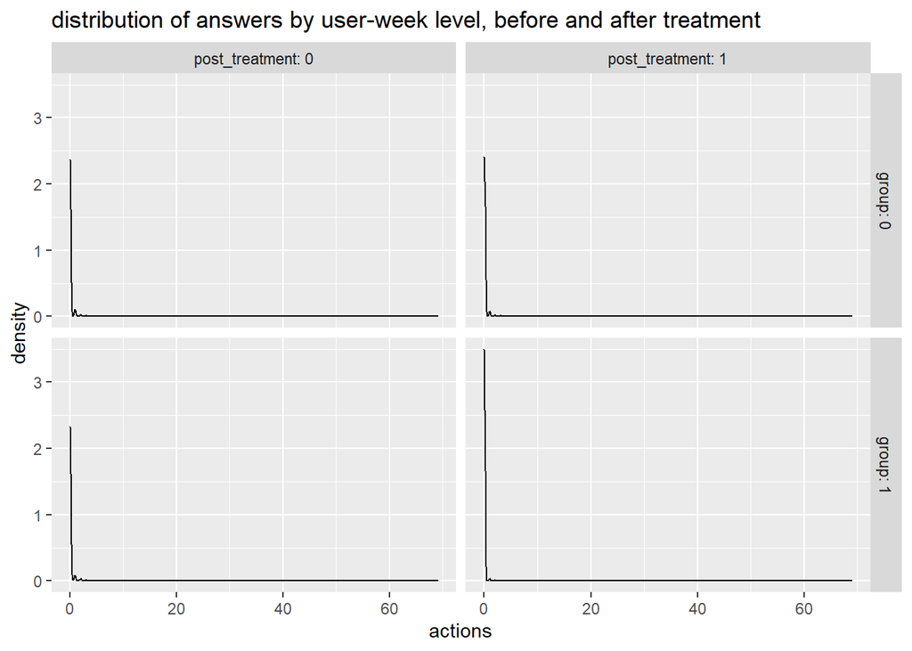

```r
#densuty plot of the two groups answering behavior, before and after the treatment
w_panel_did_qual_as_regUs_6m_b %>%
  ggplot(aes(x = actions)) +
  geom_density() +
  ggtitle("distribution of answers by user-week level, before and after treatment") +
  facet_grid(group~post_treatment, labeller = label_both)
```

a log transformation does not yield any clear improvement in terms of making the distribution of the DV more normal.

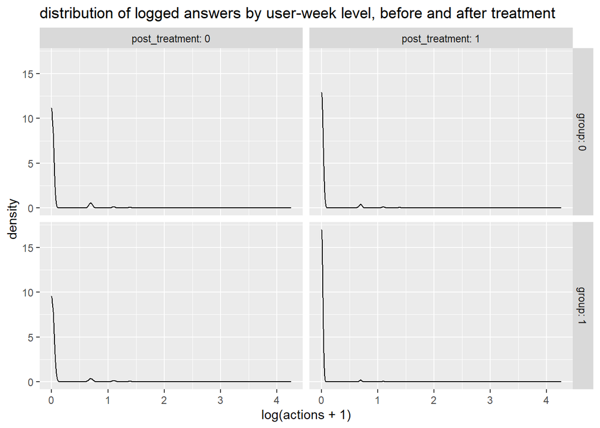

```r
#density plot of the two groups, before and after treatment, logged DV
w_panel_did_qual_as_regUs_6m_b  %>%
  ggplot(aes(x = log(actions+1))) +
  geom_density() +
  ggtitle("distribution of logged answers by user-week level, before and after treatment") +
  facet_grid(group~post_treatment, labeller = label_both)
```

when excluding 0s from the dataset, the distribution is still very right skewed.

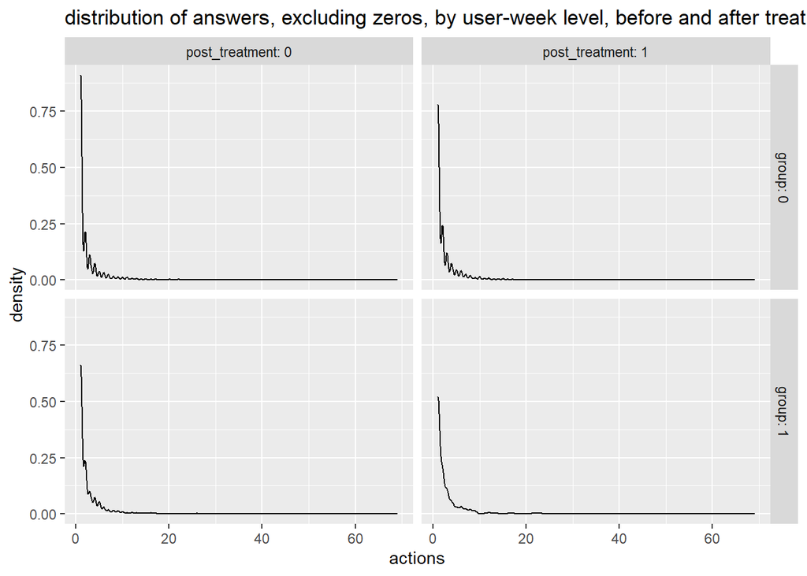

```r
#densuty plot of the two groups answering behavior, before and after the treatment
w_panel_did_qual_as_regUs_6m_b  %>% filter(actions > 0) %>%
  ggplot(aes(x = actions)) +
  geom_density() +
  ggtitle("distribution of answers, excluding zeros, by user-week level, before and after treatment") +
  facet_grid(group~post_treatment, labeller = label_both)
```

### propensity score matching

In the following section, the propensity matching procedure is undertaken and described, using matching variables based on the available data. Unfortunately, there is no demopgraphic data available on the user level, which is why information on the contribution behavior is used to undertake the propensity score matching.

The preparation of the data used to conduct the propensity was done outside of the statistical report. The reason being is that while the analysis is being done on panel data, the matching was conducted with crosssectional data. The data for the crosssectional matching procedure is based on the following variables:

- Days since a user was registered to the community
- average words per answer
- number of original posts made by a user between registration and time of incentive introduction
- overall number of answers made by a user between registration and time of incentive introduction
- number of answers made by a user 1 year before the incentive introduction
- number of answers made by a user 2 years before the incentive introduction
- number of answers made by a user 3 years before the incentive introduction

```r
#quantile propensity score calculations
m_ps_qs_2 <- glm(t_groups ~ d_since_reg_qs_2 +
                   orig_posts_qs_2 +
                   words_p_answer_qs_2 +
                   answers_total_qs_2 +
                   answers_t_1_qs_2 +
                   answers_t_2_qs_2 +
                   answers_t_3_qs_2,
                 family = binomial(), data = crosssec_both_match)




#unaltered propensity score calculations
m_ps_unalt_1 <- glm(t_groups ~  d_since_reg +
                      orig_posts +
                      words_p_answer +
                      answers_total +
                      answers_t_1 +
                      answers_t_2 +
                      answers_t_3, family = binomial(), data = crosssec_both_match)

summary(m_ps_qs_2)
```

```
##
## Call:
## glm(formula = t_groups ~ d_since_reg_qs_2 + orig_posts_qs_2 +
##     words_p_answer_qs_2 + answers_total_qs_2 + answers_t_1_qs_2 +
##     answers_t_2_qs_2 + answers_t_3_qs_2, family = binomial(),
##     data = crosssec_both_match)
##
## Deviance Residuals:
##     Min       1Q   Median       3Q      Max
## -1.4291  -0.7846  -0.6687   1.1658   2.4150
##
## Coefficients:
##                      Estimate Std. Error z value Pr(>|z|)
## (Intercept)          -0.52747    0.16782  -3.143 0.001671 **
## d_since_reg_qs_22    -0.04275    0.12564  -0.340 0.733632
## d_since_reg_qs_23    -0.04367    0.12638  -0.346 0.729660
## d_since_reg_qs_24     0.22247    0.14389   1.546 0.122067
## d_since_reg_qs_25     0.75788    0.15406   4.919 8.68e-07 ***
## orig_posts_qs_22     -0.36290    0.12281  -2.955 0.003127 **
## orig_posts_qs_23     -0.48414    0.10585  -4.574 4.79e-06 ***
## words_p_answer_qs_22  0.19762    0.14925   1.324 0.185473
## words_p_answer_qs_23  0.13241    0.15274   0.867 0.385976
## words_p_answer_qs_24  0.11998    0.15547   0.772 0.440259
## words_p_answer_qs_25  0.12061    0.15279   0.789 0.429886
## answers_total_qs_22  -0.83616    0.18690  -4.474 7.68e-06 ***
## answers_total_qs_23  -0.71919    0.28346  -2.537 0.011175 *
## answers_total_qs_24  -1.06144    0.28938  -3.668 0.000244 ***
## answers_total_qs_25  -1.06162    0.32857  -3.231 0.001234 **
## answers_t_1_qs_22     0.93100    0.22344   4.167 3.09e-05 ***
## answers_t_1_qs_23     1.12741    0.22524   5.005 5.58e-07 ***
## answers_t_2_qs_22    -0.35321    0.15565  -2.269 0.023251 *
## answers_t_3_qs_22    -1.31187    0.19415  -6.757 1.41e-11 ***
## ---
## Signif. codes:  0 '***' 0.001 '**' 0.01 '*' 0.05 '.' 0.1 ' ' 1
##
## (Dispersion parameter for binomial family taken to be 1)
##
##     Null deviance: 3968.6  on 3419  degrees of freedom
## Residual deviance: 3750.0  on 3401  degrees of freedom
## AIC: 3788
##
## Number of Fisher Scoring iterations: 4
```

In the quantiled version of the variables above, in which each quantile is treated as a factor, the “total number of answers” variable was highly significant in predicting whether a user resembled belonging to the treated community. The negative coefficient shows that user in the untreated community tend to contribute more answers than users in the treated community. Words per answer on the other hand was a weak predictor for wether a user was resembled being part of the treated community, implying that the number of words per answer is relatively similar for users in either community.

```r
summary(m_ps_unalt_1)
```

```
##
## Call:
## glm(formula = t_groups ~ d_since_reg + orig_posts + words_p_answer +
##     answers_total + answers_t_1 + answers_t_2 + answers_t_3,
##     family = binomial(), data = crosssec_both_match)
##
## Deviance Residuals:
##     Min       1Q   Median       3Q      Max
## -1.7603  -0.8314  -0.6074   1.0444   6.8444
##
## Coefficients:
##                  Estimate Std. Error z value Pr(>|z|)
## (Intercept)    -0.4374119  0.0715684  -6.112 9.85e-10 ***
## d_since_reg     0.0006433  0.0001009   6.373 1.86e-10 ***
## orig_posts      0.0214552  0.0042852   5.007 5.53e-07 ***
## words_p_answer -0.0103173  0.0007249 -14.233  < 2e-16 ***
## answers_total  -0.0433531  0.0141865  -3.056 0.002243 **
## answers_t_1     0.0480618  0.0144852   3.318 0.000907 ***
## answers_t_2     0.0392952  0.0144493   2.720 0.006538 **
## answers_t_3     0.0311843  0.0167245   1.865 0.062238 .
## ---
## Signif. codes:  0 '***' 0.001 '**' 0.01 '*' 0.05 '.' 0.1 ' ' 1
##
## (Dispersion parameter for binomial family taken to be 1)
##
##     Null deviance: 3968.6  on 3419  degrees of freedom
## Residual deviance: 3547.5  on 3412  degrees of freedom
## AIC: 3563.5
##
## Number of Fisher Scoring iterations: 8
```

Looking at the coefficients of the model above, including the variables in continuous (unaltered) form, every variable is significant at least at the 90% confidence level.

For the matching procedure, a number of different options are available, including nearest neighbor optimal, nearest neighbor ordered and coarsened exact matching just to name a few. Similar to the case above, the selection process was based on running various matching procedures with different combinations of variables, in unaltered, qunatiled and standardized form. Once again, only the final matching procedures are presented in this report, which are ordered nearest neighbor matching with the combination of variables as presented above, in unaltered and quantiled form. Here, ordered refers to the fact that the observations were sorted in descending order according to their propensity scores, which were predicted using the regression models from above.

What follows is the ordered nearest neighbor matching procedure using the variables in their unaltered, continuous form. The information presented below gives an exhaustive overview of the descriptive statistics for every variable included in the matching procedure before and after matching as well as the balance improvement (or decrease) after matching .

```r
##execute NN matching ordered for un-quantiled, un-scaled with best fitting model
crosssec_both_match$PS_unalt <- predict(m_ps_unalt_1)
crosssec_both_match_unalt_ord <- crosssec_both_match %>% arrange(desc(PS_unalt))

#execute the matching by nearest neighbour
crosssec_both_match_unalt_ord_NoNas <- crosssec_both_match_unalt_ord %>% dplyr::select(c(-views_p_post, -p_views_qs, -p_views_qs_2, -words_p_all_posts))

NN_match_unalt_ord <- matchit(t_groups ~  d_since_reg +
                                orig_posts +
                                words_p_answer +
                                answers_total +
                                answers_t_1 +
                                answers_t_2 +
                                answers_t_3, method = "nearest", data = crosssec_both_match_unalt_ord_NoNas)

summary(NN_match_unalt_ord)
```

```
##
## Call:
## matchit(formula = t_groups ~ d_since_reg + orig_posts + words_p_answer +
##     answers_total + answers_t_1 + answers_t_2 + answers_t_3,
##     data = crosssec_both_match_unalt_ord_NoNas, method = "nearest")
##
## Summary of balance for all data:
##                Means Treated Means Control SD Control Mean Diff eQQ Med
## distance              0.3586        0.2336     0.1325    0.1250  0.1253
## d_since_reg         452.1687      381.4962   438.4735   70.6725 13.0000
## orig_posts            6.1172        2.8133     8.6969    3.3039  1.0000
## words_p_answer       61.9190      123.2938   124.9330  -61.3748 52.0000
## answers_total        11.1457       22.0319   127.8398  -10.8862  0.0000
## answers_t_1           5.9496        7.0104    37.8235   -1.0608  0.0000
## answers_t_2           3.7152        5.8026    47.3766   -2.0873  0.0000
## answers_t_3           1.0022        4.8452    36.4309   -3.8430  0.0000
##                eQQ Mean   eQQ Max
## distance         0.1250    0.3291
## d_since_reg     70.5882  336.0000
## orig_posts       3.2574  475.0000
## words_p_answer  63.4457  863.0000
## answers_total   12.0131 2583.0000
## answers_t_1      2.0887  645.0000
## answers_t_2      2.8434 1291.0000
## answers_t_3      4.0011  609.0000
##
##
## Summary of balance for matched data:
##                Means Treated Means Control SD Control Mean Diff eQQ Med
## distance              0.3586        0.3392     0.1178    0.0194  0.0097
## d_since_reg         452.1687      414.7700   439.6357   37.3987 16.0000
## orig_posts            6.1172        3.9365    10.6651    2.1807  0.0000
## words_p_answer       61.9190       61.6836    65.2938    0.2355  3.0000
## answers_total        11.1457        9.1610    47.9420    1.9847  1.0000
## answers_t_1           5.9496        4.6386    21.4018    1.3111  1.0000
## answers_t_2           3.7152        2.0657    13.0408    1.6495  0.0000
## answers_t_3           1.0022        1.2453    11.1373   -0.2432  0.0000
##                eQQ Mean   eQQ Max
## distance         0.0194    0.2708
## d_since_reg     51.9157  399.0000
```

[output cut: 9 more lines]

```
## distance          84.4697  92.2212  84.4398  17.7051
## d_since_reg       47.0817 -23.0769  26.4527 -18.7500
## orig_posts        33.9950 100.0000  30.1614   0.0000
## words_p_answer    99.6164  94.2308  89.8368 -75.4345
## answers_total     81.7690     -Inf  77.3341  87.2629
## answers_t_1      -23.5972     -Inf  22.5485  86.2016
## answers_t_2       20.9752   0.0000  40.7550  88.3036
## answers_t_3       93.6729   0.0000  87.7909  84.0722
##
## Sample sizes:
##           Control Treated
## All          2507     913
## Matched       913     913
## Unmatched    1594       0
## Discarded       0       0
```

from the above matching output, when comparing the mean differences and balance improvements of the control group, it can be seen that a considerable improvement in the balance of the matching variables has been achieved with the matching procedure. Below, a visual representation of the propensity score changes before and after matching for the matching procedure based on the unaltered, continuous variables, is provided.

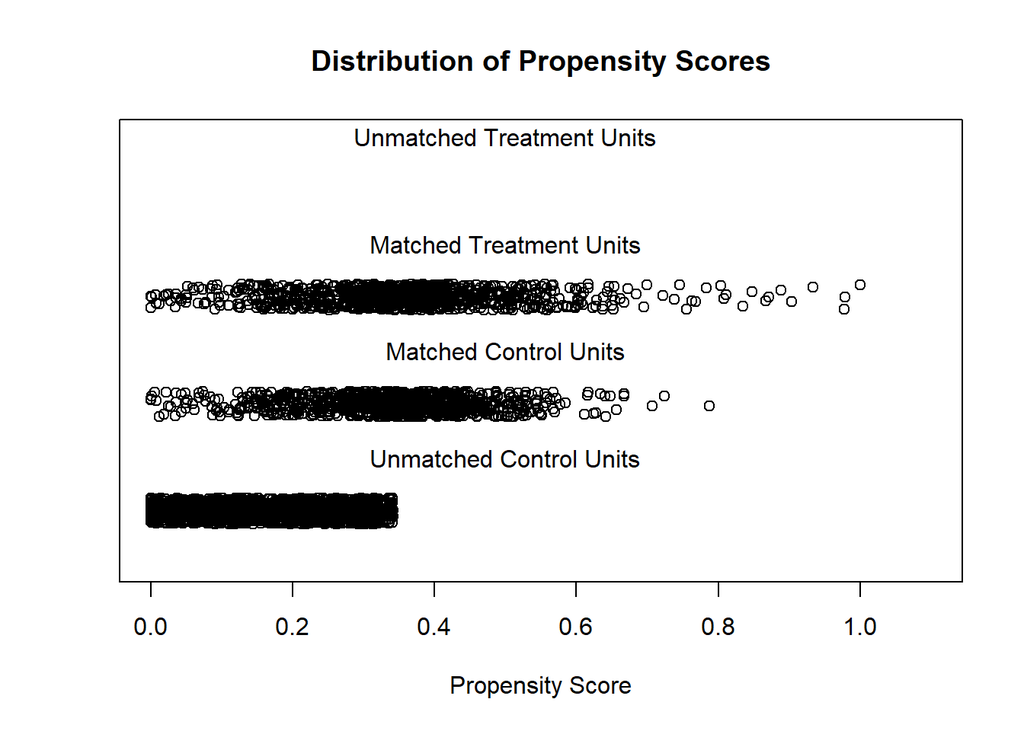

```r
plot(NN_match_unalt_ord, type = "jitter", interactive = F)
```

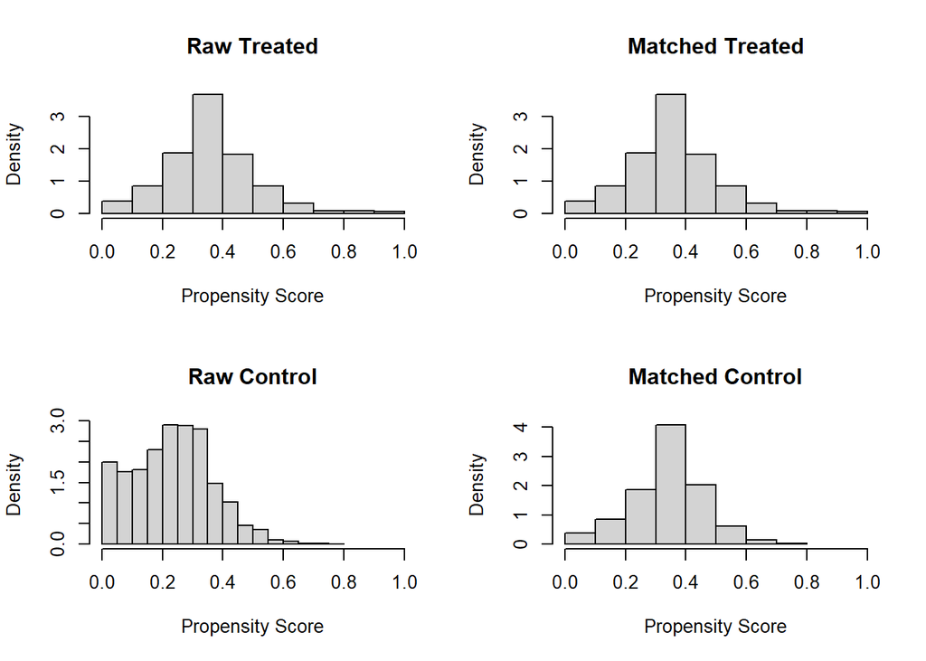

```r
plot(NN_match_unalt_ord, type = "hist")
```

The visual comparison shows a far more balanced distribution of the propensity scores after matching. The first graphic clearly shows that a large number of observations with very low propensity scores was purged from the control group. However, there remain a number of observations with very high propensity scores in the treatment group, which were not able to be matched with observations in the control group that had a similarly high propensity score.

Next, the ordered nearest neighbor matching procedure using the variables as coerced into factors according to quantiles is presented

```r
crosssec_both_match$PS <- predict(m_ps_qs_2)

crosssec_both_match_ord <- crosssec_both_match %>% arrange(desc(PS))

##execute the matching by nearest neighbor with quantiles after ordering
matching_panel_both_ord_noNas <- crosssec_both_match_ord %>% dplyr::select(c(-views_p_post, -p_views_qs, -p_views_qs_2, -words_p_all_posts))

NN_match_qs_ord <- matchit(t_groups ~ d_since_reg_qs_2 +
                             orig_posts_qs_2 +
                             words_p_answer_qs_2 +
                             answers_total_qs_2 +
                             answers_t_1_qs_2 +
                             answers_t_2_qs_2 +
                             answers_t_3_qs_2, method = "nearest", data = matching_panel_both_ord_noNas)

summary(NN_match_qs_ord)
```

```
##
## Call:
## matchit(formula = t_groups ~ d_since_reg_qs_2 + orig_posts_qs_2 +
##     words_p_answer_qs_2 + answers_total_qs_2 + answers_t_1_qs_2 +
##     answers_t_2_qs_2 + answers_t_3_qs_2, data = matching_panel_both_ord_noNas,
##     method = "nearest")
##
## Summary of balance for all data:
##                      Means Treated Means Control SD Control Mean Diff eQQ Med
## distance                    0.3152        0.2494     0.1026    0.0658  0.0564
## d_since_reg_qs_21           0.2026        0.2006     0.4006    0.0020  0.0000
## d_since_reg_qs_22           0.1982        0.1994     0.3997   -0.0012  0.0000
## d_since_reg_qs_23           0.1993        0.1998     0.4000   -0.0005  0.0000
## d_since_reg_qs_24           0.1993        0.1998     0.4000   -0.0005  0.0000
## d_since_reg_qs_25           0.2004        0.2002     0.4003    0.0002  0.0000
## orig_posts_qs_22            0.1347        0.1484     0.3556   -0.0137  0.0000
## orig_posts_qs_23            0.2432        0.3004     0.4585   -0.0572  0.0000
## words_p_answer_qs_22        0.2004        0.1990     0.3994    0.0014  0.0000
## words_p_answer_qs_23        0.1993        0.1990     0.3994    0.0003  0.0000
## words_p_answer_qs_24        0.1993        0.2002     0.4003   -0.0009  0.0000
## words_p_answer_qs_25        0.2004        0.1998     0.4000    0.0006  0.0000
## answers_total_qs_22         0.3713        0.4986     0.5001   -0.1273  0.0000
## answers_total_qs_23         0.1665        0.0993     0.2992    0.0672  0.0000
## answers_total_qs_24         0.1862        0.1460     0.3532    0.0402  0.0000
## answers_total_qs_25         0.1796        0.1927     0.3945   -0.0130  0.0000
## answers_t_1_qs_22           0.1698        0.0941     0.2921    0.0756  0.0000
## answers_t_1_qs_23           0.3133        0.2401     0.4272    0.0731  0.0000
## answers_t_2_qs_22           0.1544        0.2134     0.4098   -0.0590  0.0000
## answers_t_3_qs_22           0.0602        0.1384     0.3454   -0.0782  0.0000
##                      eQQ Mean eQQ Max
## distance               0.0659  0.1335
## d_since_reg_qs_21      0.0022  1.0000
## d_since_reg_qs_22      0.0011  1.0000
## d_since_reg_qs_23      0.0000  0.0000
## d_since_reg_qs_24      0.0000  0.0000
## d_since_reg_qs_25      0.0000  0.0000
## orig_posts_qs_22       0.0142  1.0000
## orig_posts_qs_23       0.0570  1.0000
## words_p_answer_qs_22   0.0011  1.0000
## words_p_answer_qs_23   0.0000  0.0000
```

[output cut: 70 more lines]

```
## answers_total_qs_22    100.0000       0   100.0000 100.0000
## answers_total_qs_23     90.2151       0    90.1639   0.0000
## answers_total_qs_24     10.1063       0    10.8108   0.0000
## answers_total_qs_25    -34.4641       0   -33.3333   0.0000
## answers_t_1_qs_22       79.7259       0    79.7101   0.0000
## answers_t_1_qs_23       47.5761       0    47.7612   0.0000
## answers_t_2_qs_22       64.7079       0    64.8148   0.0000
## answers_t_3_qs_22       97.1977       0    97.1831   0.0000
##
## Sample sizes:
##           Control Treated
## All          2507     913
## Matched       913     913
## Unmatched    1594       0
## Discarded       0       0
```

The balance improvement using the factor variables is not as clear when taking the “percent balance improvement” table at face value. However it has to be said that the number of variables to match on increased significantly due to every factor level being matched on. In addition, the absolute differences are far smaller before and after the matching procedure when inspecting means in the first two tables. Overall, the balance improved for 11 of 19 factor levels.

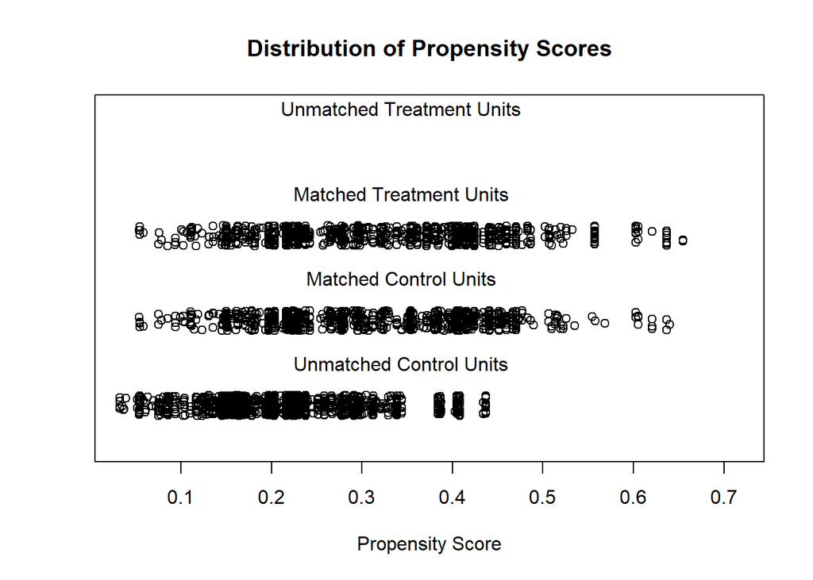

```r
plot(NN_match_qs_ord, type = "jitter", interactive = F)
```

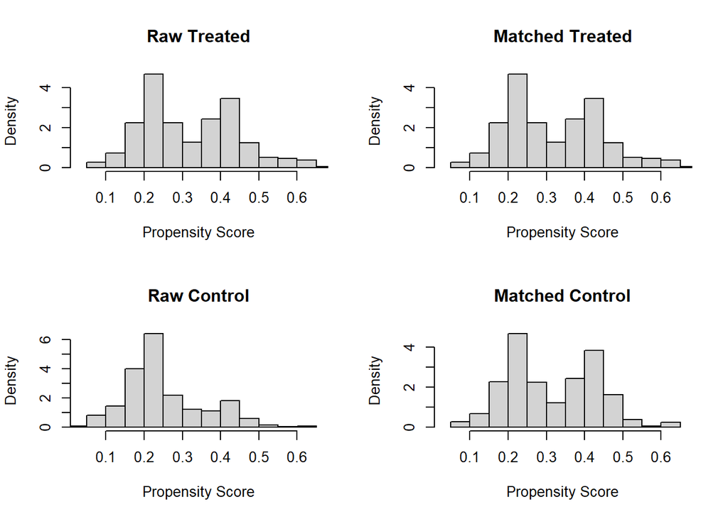

```r
plot(NN_match_qs_ord, type = "hist")
```

Visually on the other hand, the balance improvement after matching is promising when inspecting the propensity scores. As before, a large number of control group observations with low propensity scores were purged from the dataset, while at the same time the high propensity score observations of the treatment group could be matched more closely with control group observations compared to the matching based on the unaltered, continuous variables. Comparing the histograms in the second graphic also illustrates the considerable improvements in balance of the two groups due to the matching procedure

### Descriptives - panel data including only matched observations

Following the comparison of the propensity scores before and after matching for the control and treated group, it makes sense to inspect whether this improvement in balance translates into improved balance in the descriptive statistics, at least before the introduction of the treatment. Below an overview of the descriptive statistics for the panel data based on the matching procedure with the unaltered, continuous variables is provided. Given the visual inspection was not particularly helpful due to the large right skew of the dependent variable, only the descriptive statistics tables are provided

```r
#extracting the matching data
match_data_unalt <- match.data(NN_match_unalt_ord)

#limiting the panel data to the matched unaltered users
w_panel_matched_qual_6m_unalt_b <- w_panel_did_qual_as_regUs_6m_b %>% filter(user_ID %in% match_data_unalt$user_ID)

#providing the descriptive statistics
  stargazer(w_panel_matched_qual_6m_unalt_b %>% filter(group == 1, post_treatment == 0) %>% dplyr::select(t_shock_w, post_treatment, actions, questions_per_week),
            type = "html",
            title ="Descriptive Statistics treated community, before shock",
            digits = 2,
            font.size = "normalsize",
            single.row = TRUE,
            notes = "",
            column.separate = c(4, 1, 1, 1, 1, 1),
            summary.stat = c("n","mean","sd", "min","max", "median"))
```

**Descriptive Statistics treated community, before shock**

| Statistic | N | Mean | St. Dev. | Min | Max | Median |
| --- | --- | --- | --- | --- | --- | --- |
| t_shock_w | 21,912 | -12.50 | 6.92 | -24 | -1 | -12.5 |
| post_treatment | 21,912 | 0.00 | 0.00 | 0 | 0 | 0 |
| actions | 21,912 | 0.19 | 1.17 | 0 | 45 | 0 |
| questions_per_week | 21,912 | 24.79 | 11.46 | 4 | 53 | 26 |

```r
#descriptives for the treatment group, after treatment
  stargazer(w_panel_matched_qual_6m_unalt_b %>% filter(group == 1, post_treatment == 1) %>% dplyr::select(t_shock_w, post_treatment, actions, questions_per_week),
            type = "html",
            title ="Descriptive Statistics treated community, after shock",
            digits = 2,
            font.size = "normalsize",
            single.row = TRUE,
            notes = "",
            column.separate = c(4, 1, 1, 1, 1, 1),
            summary.stat = c("n","mean","sd", "min","max", "median"))
```

**Descriptive Statistics treated community, after shock**

| Statistic | N | Mean | St. Dev. | Min | Max | Median |
| --- | --- | --- | --- | --- | --- | --- |
| t_shock_w | 21,912 | 11.50 | 6.92 | 0 | 23 | 11.5 |
| post_treatment | 21,912 | 1.00 | 0.00 | 1 | 1 | 1 |
| actions | 21,912 | 0.06 | 0.63 | 0 | 23 | 0 |
| questions_per_week | 21,912 | 6.46 | 2.83 | 2 | 13 | 6.5 |

```r
#descriptives for the control group, before treatment
  stargazer(w_panel_matched_qual_6m_unalt_b %>% filter(group == 0, post_treatment == 0) %>% dplyr::select(t_shock_w, post_treatment, actions, questions_per_week),
            type = "html",
            title ="Descriptive Statistics control community, before shock",
            digits = 2,
            font.size = "normalsize",
            single.row = TRUE,
            notes = "",
            column.separate = c(4, 1, 1, 1, 1, 1),
            summary.stat = c("n","mean","sd", "min","max", "median"))
```

**Descriptive Statistics control community, before shock**

| Statistic | N | Mean | St. Dev. | Min | Max | Median |
| --- | --- | --- | --- | --- | --- | --- |
| t_shock_w | 20,616 | -12.50 | 6.92 | -24 | -1 | -12.5 |
| post_treatment | 20,616 | 0.00 | 0.00 | 0 | 0 | 0 |
| actions | 20,616 | 0.14 | 1.14 | 0 | 69 | 0 |
| questions_per_week | 20,616 | 92.12 | 13.29 | 71 | 119 | 90.5 |

```r
#descriptives for the control group, after treatment
  stargazer(w_panel_matched_qual_6m_unalt_b %>% filter(group == 0, post_treatment == 1) %>% dplyr::select(t_shock_w, post_treatment, actions, questions_per_week),
            type = "html",
            title ="Descriptive Statistics control community, before shock",
            digits = 2,
            font.size = "normalsize",
            single.row = TRUE,
            notes = "",
            column.separate = c(4, 1, 1, 1, 1, 1),
            summary.stat = c("n","mean","sd", "min","max", "median"))
```

| Statistic | N | Mean | St. Dev. | Min | Max | Median |
| --- | --- | --- | --- | --- | --- | --- |
| t_shock_w | 20,622 | 11.50 | 6.92 | 0 | 23 | 11 |
| post_treatment | 20,622 | 1.00 | 0.00 | 1 | 1 | 1 |
| actions | 20,622 | 0.09 | 0.64 | 0 | 21 | 0 |
| questions_per_week | 20,622 | 66.63 | 13.35 | 47 | 97 | 65 |

As shown in the descriptive statistics table, there is little improvement in terms of similarity of means in the DV as well as the control variable, questions per week. However, the standard deviations for the DV in the treated and control community are more similar than before.

Finally, the descriptive statistics for the treated and control community are provided based on observations that were matched on the factor variables constructed from quantiles of the matching variables.

```r
#extracting the matching data
match_data_qs <- match.data(NN_match_qs_ord)

#including only the observations of the matching procedure
w_panel_matched_qual_6m_qs_b <- w_panel_did_qual_as_regUs_6m_b %>% filter(user_ID %in% match_data_qs$user_ID)

#providing the descriptive statistics
  stargazer(w_panel_matched_qual_6m_qs_b %>% filter(group == 1, post_treatment == 0) %>% dplyr::select(t_shock_w, post_treatment, actions, questions_per_week),
            type = "html",
            title ="Descriptive Statistics treated community, before shock",
            digits = 2,
            font.size = "normalsize",
            single.row = TRUE,
            notes = "",
            column.separate = c(4, 1, 1, 1, 1, 1),
            summary.stat = c("n","mean","sd", "min","max", "median"))
```

**Descriptive Statistics treated community, before shock**

| Statistic | N | Mean | St. Dev. | Min | Max | Median |
| --- | --- | --- | --- | --- | --- | --- |
| t_shock_w | 21,912 | -12.50 | 6.92 | -24 | -1 | -12.5 |
| post_treatment | 21,912 | 0.00 | 0.00 | 0 | 0 | 0 |
| actions | 21,912 | 0.19 | 1.17 | 0 | 45 | 0 |
| questions_per_week | 21,912 | 24.79 | 11.46 | 4 | 53 | 26 |

```r
#descriptives for the treatment group, after treatment
  stargazer(w_panel_matched_qual_6m_qs_b %>% filter(group == 1, post_treatment == 1) %>% dplyr::select(t_shock_w, post_treatment, actions, questions_per_week),
            type = "html",
            title ="Descriptive Statistics treated community, after shock",
            digits = 2,
            font.size = "normalsize",
            single.row = TRUE,
            notes = "",
            column.separate = c(4, 1, 1, 1, 1, 1),
            summary.stat = c("n","mean","sd", "min","max", "median"))
```

**Descriptive Statistics treated community, after shock**

| Statistic | N | Mean | St. Dev. | Min | Max | Median |
| --- | --- | --- | --- | --- | --- | --- |
| t_shock_w | 21,912 | 11.50 | 6.92 | 0 | 23 | 11.5 |
| post_treatment | 21,912 | 1.00 | 0.00 | 1 | 1 | 1 |
| actions | 21,912 | 0.06 | 0.63 | 0 | 23 | 0 |
| questions_per_week | 21,912 | 6.46 | 2.83 | 2 | 13 | 6.5 |

```r
#descriptives for the control group, before treatment
  stargazer(w_panel_matched_qual_6m_qs_b %>% filter(group == 0, post_treatment == 0) %>% dplyr::select(t_shock_w, post_treatment, actions, questions_per_week),
            type = "html",
            title ="Descriptive Statistics control community, before shock",
            digits = 2,
            font.size = "normalsize",
            single.row = TRUE,
            notes = "",
            column.separate = c(4, 1, 1, 1, 1, 1),
            summary.stat = c("n","mean","sd", "min","max", "median"))
```

**Descriptive Statistics control community, before shock**

| Statistic | N | Mean | St. Dev. | Min | Max | Median |
| --- | --- | --- | --- | --- | --- | --- |
| t_shock_w | 20,880 | -12.50 | 6.92 | -24 | -1 | -12.5 |
| post_treatment | 20,880 | 0.00 | 0.00 | 0 | 0 | 0 |
| actions | 20,880 | 0.28 | 1.80 | 0 | 69 | 0 |
| questions_per_week | 20,880 | 92.12 | 13.29 | 71 | 119 | 90.5 |

```r
#descriptives for the control group, after treatment
  stargazer(w_panel_matched_qual_6m_qs_b %>% filter(group == 0, post_treatment == 1) %>% dplyr::select(t_shock_w, post_treatment, actions, questions_per_week),
            type = "html",
            title ="Descriptive Statistics control community, before shock",
            digits = 2,
            font.size = "normalsize",
            single.row = TRUE,
            notes = "",
            column.separate = c(4, 1, 1, 1, 1, 1),
            summary.stat = c("n","mean","sd", "min","max", "median"))
```

| Statistic | N | Mean | St. Dev. | Min | Max | Median |
| --- | --- | --- | --- | --- | --- | --- |
| t_shock_w | 20,898 | 11.49 | 6.93 | 0 | 23 | 11 |
| post_treatment | 20,898 | 1.00 | 0.00 | 1 | 1 | 1 |
| actions | 20,898 | 0.21 | 1.63 | 0 | 54 | 0 |
| questions_per_week | 20,898 | 66.65 | 13.36 | 47 | 97 | 65 |

As can be seen above, the mean as well as standard deviation of the dependent variable increased compared to before the matching procedure in the control group, both before and after incentive introduction. This may mean that the matching procedure made the two groups less comparable, or that there are substantial differences in levels of answering activity within the control group. This suggests that individual fixed effects may need to be included in the difference in difference analysis when using the panel data including observations from the matching procedure based on quantiles. In the remainder of this statistical report, the performance analysis will be based on the sample created from the matching procedure with unaltered data (i.e. not quantiled). The reason being that although the intention of creating quantiles of the variables was well intentioned, the distributions of the matching variables didn’t allow for the creation of the same number of quantiles across all variables (e.g. for the variable “answers 3 years before the shock”). This was deemed as too hard to justify theoretically.

What follows in the next section will be the analysis of how the introduction of symbolic awards affects the answering behavior of members within online communities. The matching procedures illustrated above, in addition to the pre-processing of the raw data, provide further arguments for the identification of a generalizable causal effect.

# Analysis

### Hypothesis to test

To test the hypothesis of this research, that the introduction of symbolic awards has a negative effect on the answering behavior of members, a difference in difference design is employed, which translates into the following regression equation:

$$answers_{it} = \delta_{1}treatment_{t} + \delta_{2}group_{i} + \delta_{3}(group_{i}*treatment_{t}) + \beta_{1}questions_{t} + \alpha_{t} + \gamma_{i} + \epsilon_{i}$$

in this equation, the coefficient of interest is $\delta_{3}$ which represents the difference in difference coefficient, i.e. the treatement effect on the treated. Given assumptions on parallel pretrends hold, this coefficient should give an estimate for the change in average weekly answering behavior of users after the introduction of badges. Questions per week are included as a control variable, to control for any changes in answering behavior that may be driven by the availability of questions during a specific time period. In the above full equation, individual and time fixed effects as well as errors clustered on the individual level are used, represented by $\alpha_{t}$, $\gamma_{i}$ and $\epsilon_{i}$ respectively. Errors are clustered on the individual level, as there is grounds to believe that errors may be correlated over time by individual.

### Pre-assessment of dependent variable distribution

Given the non-negative integer values the dependent variable takes on, and taking into account the right tail skeweness of its distribution shown above, it makes sense to choose a model which is more suitable than an OLS regression specification. There are a number of options available that rely on more suitable distributional properties to model the residuals, which is why it makes sense to investigate the dependent variable in more detail before deciding on a specification.

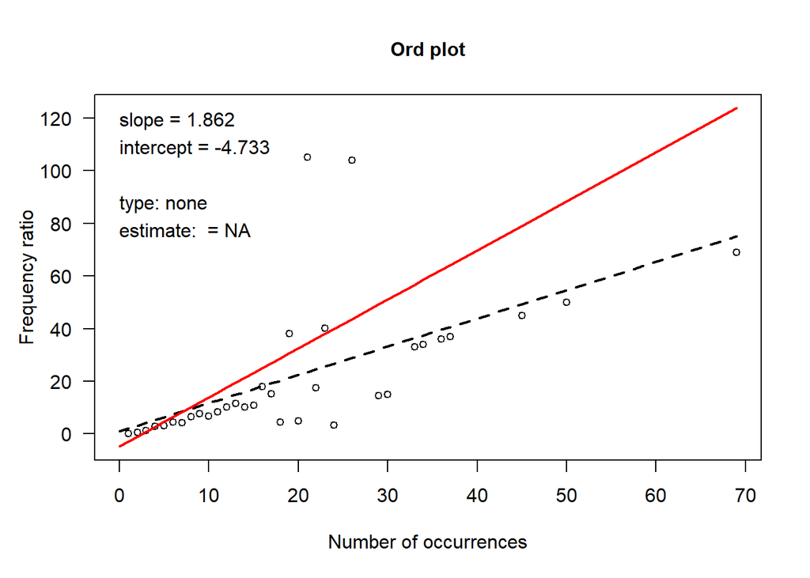

```r
dv <- w_panel_matched_qual_6m_unalt_b$actions

par(mfrow = c(3, 1))
#show ord plot
Ord_plot(dv)
```

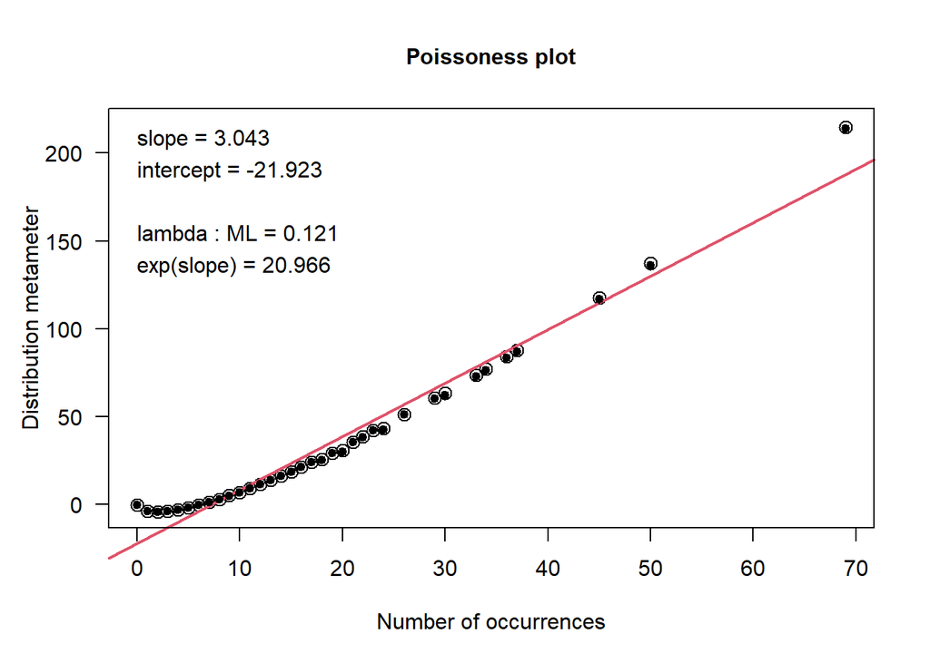

```r
#the "xxxxness" plot, using poisson
distplot(dv, type = "poisson")
```

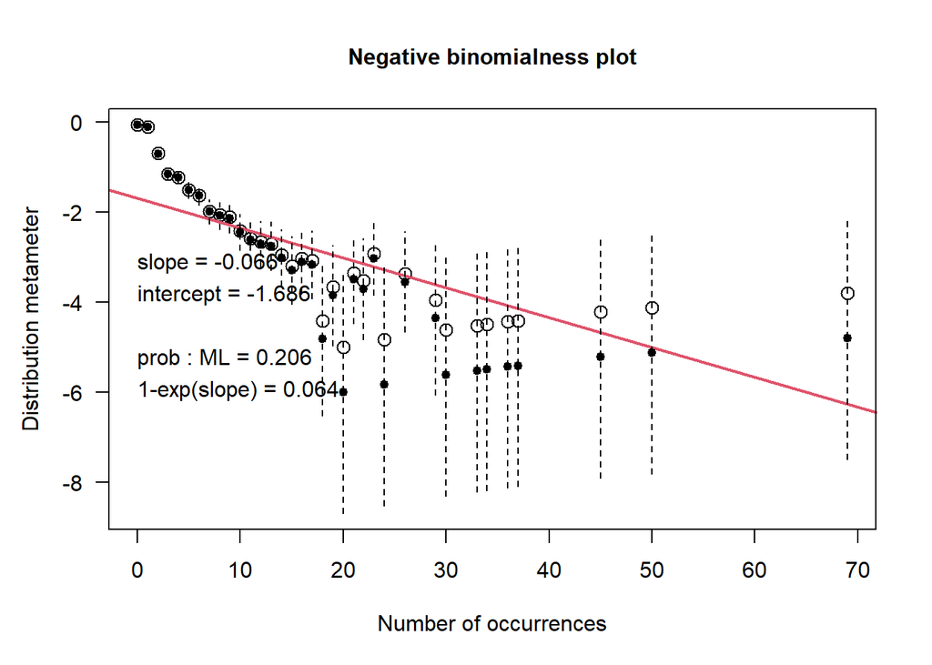

```r
#the "xxxxxness" plot, using nbin
distplot(dv, type = "nbinom")
```

```r
par(mfrow = c(1, 1))

#the goodfit function poisson
summary(goodfit(dv))
```

```
##
##   Goodness-of-fit test for poisson distribution
##
##                       X^2 df P(> X^2)
## Likelihood Ratio 36950.14 33        0
```

```r
#the goodfit function nbin
summary(goodfit(dv, type = "nbinom"))
```

```
##
##   Goodness-of-fit test for nbinomial distribution
##
##                       X^2 df     P(> X^2)
## Likelihood Ratio 337.6829 32 1.020734e-52
```

The above plots give a summary of the distribution of the depenedent variable to assess which model is the best choice given the distribution. The Ord Plot, which plots the number of occurrences against a frequency ratio, suggest that a logarithmic series might fit the DV distribution best. However the ord plot is sensitive to single outlier values, which is why dist plots provide better indications for which distribution the variable may follow (see Friendly, 2000). Checking these plots as well as the likelihood provided for both the poisson and negative binomial in the “goodness-of-fit” test, it is more likely that the answer variable follows a negative binomial distribution.

### Model building and testing

Below, a number of different regression specifications are calculated for the main equation shown above. OLS regressions are shown as baseline models, with and without fixed effects. The reason why both are shown is, that the inclusion of individual fixed effects makes intuitive sense in order to control for any difference in levels between member’s answering behavior in the two communities. However, including them also leads to the exclusion of individuals that that don’t show any variance in their answering behavior in either the pre-treatment or post-treatment period. A large number of users in the sample only are active once, and some member are active multiple times but only in one of the two periods. Hence, the sample size is reduced considerably when including these individual fixed effects, effectively leading to the diff-in-diff coefficient measuring only the change in answering behavior of members that portray an above average activity level.

Poisson and Negative binomial models, which are more suitable given the distributional properties of the dv of interest, are shown with and without fixed effects as well. Finally, the results of hurdle models are shown, which in principle should be able to deal with the 0-inflation issue better than regular count models. A hurdle model is chosen as appropriate vs a zero inflated model as all the observations are “at risk” of producing an answer, hence 0s are assumed to have arisen due to sampling only and not due to structural reasons (Rose et al 2006).

The data after matching on unaltered (i.e. without quantiles) was used to run the models.

```r
#### unaltered data ####
#run the logged and unlogged dv models

formula_reg <- actions ~ group*post_treatment + questions_per_week
formula_log_reg <- log(actions + 1) ~  group*post_treatment + questions_per_week
formula_did_coef <- actions ~ did_coeff + questions_per_week
formula_log_did_coef <- log(actions +1) ~ did_coeff + questions_per_week

#### matched on unaltered data
# data prep
w_panel_matched_qual_6m_unalt_b$did_coeff <- w_panel_matched_qual_6m_unalt_b$group*w_panel_matched_qual_6m_unalt_b$post_treatment

### OLS regressions
#unlogged, no FEs
ols_matched_unalt_asw_6m <- lm(formula_reg, data = w_panel_matched_qual_6m_unalt_b)
#logged, no FEs
ols_logged_matched_unalt_asw_6m <- lm(formula_log_reg, data = w_panel_matched_qual_6m_unalt_b)
#logged, FEs and clustered standard errors
ols_logged_fullFEs_matched_unalt_asw_6m <- felm(log(actions + 1) ~  did_coeff + questions_per_week|user_ID + as.factor(t_shock_w)|0|user_ID, data = w_panel_matched_qual_6m_unalt_b)

### Count regressions
# poisson - without fixed effects
pois_matched_unalt_asw_6m <- glm(actions ~ group*post_treatment + questions_per_week, family = poisson, data = w_panel_matched_qual_6m_unalt_b)
# negative binomial - without fixed effects
theta_matched <- glm.nb(actions ~ group*post_treatment + questions_per_week, data = w_panel_matched_qual_6m_unalt_b)$theta
negbi_matched_unalt_asw_6m <- update(pois_matched_unalt_asw_6m, family = negative.binomial(theta_matched))
# poisson hurdle - without fixed effects
pois_h_matched_unalt_asw_6m <- hurdle(actions ~ group*post_treatment + questions_per_week, data = w_panel_matched_qual_6m_unalt_b)
#negative binomial hurdle - without fixed effects
negbi_h_matched_unalt_asw_6m <- hurdle(actions ~ group*post_treatment + questions_per_week|1, data = w_panel_matched_qual_6m_unalt_b, dist = "negbin")

#poisson - with fixed effects
pois_matched_unalt_FEs_asw_6m <- fepois(actions ~ group*post_treatment + questions_per_week|as.factor(user_ID) + as.factor(t_shock_w), w_panel_matched_qual_6m_unalt_b)
#negative binomial - with fixed effects
negbi_matched_unalt_FEs_asw_6m_1 <- fenegbin(actions ~ did_coeff + questions_per_week|as.factor(user_ID) + as.factor(t_shock_w), w_panel_matched_qual_6m_unalt_b)
# poisson hurdle - with dummies for time fixed effects
pois_h_matched_unalt_FEs_asw_6m <- pscl::hurdle(actions ~ did_coeff + questions_per_week + as.factor(t_shock_w), data = w_panel_matched_qual_6m_unalt_b)
# negbi hurdle - with dummies for time fixed effects
negbi_h_matched_unalt_FEs_asw_6m <- pscl::hurdle(actions ~ did_coeff + questions_per_week + as.factor(t_shock_w), data = w_panel_matched_qual_6m_unalt_b, dist = "negbin")

etable(pois_matched_unalt_FEs_asw_6m,
          negbi_matched_unalt_FEs_asw_6m_1,
       title= "hurdle models, Poisson and Negative Binomial specification")
```

```
##                      pois_matched_unalt.. negbi_matched_un..
## questions_per_week   0.01612*** (0.00387) 0.0136*** (0.0027)
## group:post_treatment  -0.7672*** (0.1981)
## did_coeff                                 -1.113*** (0.1231)
## Overdispersion:                                     0.216004
## Fixed-Effects:       -------------------- ------------------
## as.factor(user_ID)                    Yes                Yes
## as.factor(t_shock_w)                  Yes                Yes
## ____________________ ____________________ __________________
## Family                            Poisson          Neg. Bin.
## Observations                       85,062             85,062
## S.E. type: Clustered         by: user_ID)       by: user_ID)
## Squared Corr.                       0.402              0.317
## Pseudo R2                         0.45581            0.18839
## BIC                             86,194.62          78,543.45
```

```r
stargazer(ols_matched_unalt_asw_6m,
          ols_logged_matched_unalt_asw_6m,
          ols_logged_fullFEs_matched_unalt_asw_6m,
          pois_matched_unalt_asw_6m,
          negbi_matched_unalt_asw_6m,
          pois_h_matched_unalt_asw_6m,
          negbi_h_matched_unalt_asw_6m,
          type = "html")
```

|  | *Dependent variable:* |  |  |  |  |  |  |
| --- | --- | --- | --- | --- | --- | --- | --- |
|  | actions | log(actions + 1) |  | actions |  |  |  |
|  | *OLS* | *OLS* | *felm* | *Poisson* | *glm: Negative Binomial(0.0343)* | *hurdle* |  |
|  |  |  |  |  | *link = log* |  |  |
|  | (1) | (2) | (3) | (4) | (5) | (6) | (7) |
| group | 0.212*** | 0.072*** |  | 1.465*** | 1.428*** | 0.674*** | 0.935*** |
|  | (0.022) | (0.006) |  | (0.060) | (0.177) | (0.070) | (0.191) |
| post_treatment | 0.015 | 0.006** |  | 0.027 | 0.024 | -0.035 | -0.050 |
|  | (0.012) | (0.003) |  | (0.036) | (0.098) | (0.044) | (0.111) |
| did_coeff |  |  | -0.041*** |  |  |  |  |
|  |  |  | (0.006) |  |  |  |  |
| questions_per_week | 0.002*** | 0.001*** | 0.001*** | 0.017*** | 0.018*** | 0.007*** | 0.010*** |
|  | (0.0003) | (0.0001) | (0.0001) | (0.001) | (0.002) | (0.001) | (0.003) |
| group:post_treatment | -0.096*** | -0.042*** |  | -0.824*** | -0.800*** | 0.162*** | 0.231* |
|  | (0.013) | (0.004) |  | (0.043) | (0.110) | (0.051) | (0.137) |
| Constant | -0.086*** | -0.018** |  | -3.595*** | -3.592*** | 0.061 | -13.927 |
|  | (0.027) | (0.007) |  | (0.080) | (0.227) | (0.094) | (60.196) |
| Observations | 85,062 | 85,062 | 85,062 | 85,062 | 85,062 | 85,062 | 85,062 |
| R<sup>2</sup> | 0.004 | 0.007 | 0.324 |  |  |  |  |
| Adjusted R<sup>2</sup> | 0.004 | 0.007 | 0.309 |  |  |  |  |
| Log Likelihood |  |  |  | -40,124.520 | -22,671.710 | -25,766.070 | -22,855.990 |
| Akaike Inf. Crit. |  |  |  | 80,259.040 | 45,353.410 |  |  |
| Residual Std. Error | 0.933 (df = 85057) | 0.253 (df = 85057) | 0.211 (df = 83241) |  |  |  |  |
| F Statistic (df = 4; 85057) | 76.282*** | 146.415*** |  |  |  |  |  |
| *Note:* | p<0.1; p<0.05; p<0.01 |  |  |  |  |  |  |

Looking at the hurdle model results, which show an increase in average answering behavior, the most interesting element is not the coefficient of the count model, but of the zero/one binomial part of the model, as presented below. Interpreting the interaction term here, it can be seen that the likelihood of not providing any answers (i.e. being excluded from the count model) increases dramatically after introduction of the incentives.

```r
hurdle_summary <- summary(pois_h_matched_unalt_asw_6m)

hurdle_summary$coefficients$zero
```

```
##                         Estimate  Std. Error     z value      Pr(>|z|)
## (Intercept)          -3.93822639 0.127661904 -30.8488771 5.799288e-209
## group                 0.99249203 0.098079135  10.1192984  4.536557e-24
## post_treatment        0.02770759 0.055889774   0.4957542  6.200678e-01
## questions_per_week    0.01262344 0.001318949   9.5708282  1.060527e-21
## group:post_treatment -0.95448025 0.069965831 -13.6420912  2.250141e-42
```

The coefficients of the count regression part of the hurdle model are a little harder to interpret, as it wasn’t possible to specify time and individual fixed effects, thus inclusion or exclusion of observations was not made based on the user level, leading to a mean comparison of the two groups across two time periods, not accounting for user level panel dynamics.

It also has to be noted that the discrepancy between the coefficients in the OLS with logged DV models vs count models is driven in large part by the constant that is added to the dv in order to address the existance of 0s. When adding smaller constants than 1, the coefficient approximates the coefficient in the count models.

Below a model comparison is provided, showing the different fit parameters used to assess which of the models to choose based on the fit parameters (AIC, BIC and LR ratio)

```r
#showing the fit of the count models
LRstats(ols_matched_unalt_asw_6m,
          ols_logged_matched_unalt_asw_6m,
          ols_logged_fullFEs_matched_unalt_asw_6m,
          pois_matched_unalt_asw_6m,
          negbi_matched_unalt_asw_6m,
          pois_h_matched_unalt_asw_6m,
          negbi_h_matched_unalt_asw_6m)
```

```
## Likelihood summary table:
##                                            AIC    BIC LR Chisq    Df Pr(>Chisq)
## ols_matched_unalt_asw_6m                229590 229646   229578 85057     <2e-16
## ols_logged_matched_unalt_asw_6m           7697   7753     7685 85057          1
## ols_logged_fullFEs_matched_unalt_asw_6m -21350  -4312   -24994  1771          1
## pois_matched_unalt_asw_6m                80259  80306    80249 85057          1
## negbi_matched_unalt_asw_6m               45353  45400    45343 85057          1
## pois_h_matched_unalt_asw_6m              51552  51646    51532 85052          1
## negbi_h_matched_unalt_asw_6m             45726  45791    45712 85055          1
##
## ols_matched_unalt_asw_6m                ***
## ols_logged_matched_unalt_asw_6m
## ols_logged_fullFEs_matched_unalt_asw_6m
## pois_matched_unalt_asw_6m
## negbi_matched_unalt_asw_6m
## pois_h_matched_unalt_asw_6m
## negbi_h_matched_unalt_asw_6m
## ---
## Signif. codes:  0 '***' 0.001 '**' 0.01 '*' 0.05 '.' 0.1 ' ' 1
```

```r
#showing the model summaries of the models that did not get recognized by LRstats
summary(pois_matched_unalt_FEs_asw_6m)
```

```
## Poisson estimation, Dep. Var.: actions
## Observations: 85,062
## Fixed-effects: as.factor(user_ID): 1772,  as.factor(t_shock_w): 48
## Standard-errors: Clustered (as.factor(user_ID))
##                       Estimate Std. Error z value Pr(>|z|)
## questions_per_week    0.016118   0.003870  4.1651 0.000031 ***
## group:post_treatment -0.767248   0.198076 -3.8735 0.000107 ***
## ... 2 variables were removed because of collinearity (group and post_treatment)
## ---
## Signif. codes:  0 '***' 0.001 '**' 0.01 '*' 0.05 '.' 0.1 ' ' 1
## Log-likelihood: -22,426.89   Adj. Pseudo-R2: 0.41163
##            BIC:  86,194.62     Squared Cor.: 0.40206
```

```r
summary(negbi_matched_unalt_FEs_asw_6m_1)
```

```
## Negative Binomial ML estimation, Dep. Var.: actions
## Observations: 85,062
## Fixed-effects: as.factor(user_ID): 1772,  as.factor(t_shock_w): 48
## Standard-errors: Clustered (as.factor(user_ID))
##                     Estimate Std. Error z value  Pr(>|z|)
## did_coeff          -1.112800   0.123082 -9.0409 < 2.2e-16 ***
## questions_per_week  0.013597   0.002700  5.0366  4.74e-07 ***
## ---
## Signif. codes:  0 '***' 0.001 '**' 0.01 '*' 0.05 '.' 0.1 ' ' 1
## Over-dispersion parameter: theta = 0.2160042
## Log-likelihood: -18,589.95   Adj. Pseudo-R2: 0.10889
##            BIC:  78,543.45     Squared Cor.: 0.31706
```

In summary, model selection can’t be driven entirely by fit parameters, but has to be guided by the researchers understanding of the data being analyzed and the suitability of the models given the data. What follows is an investigation of the error distribution as well as predictive ability of the count regression models to offer further insights for choosing the best model.

#### Preconditions

Below, the qq plot for the residuals as well as the comparison of fitted vs actual answers of the logged DV and unlogged model (with fixed effects) are presented to illustrate non-normality (and hence untrustworthiness of standard errors). Furthermore, the rootograms of the count models are presented, which can be used to assess the predictive capabilities of the underlying models.

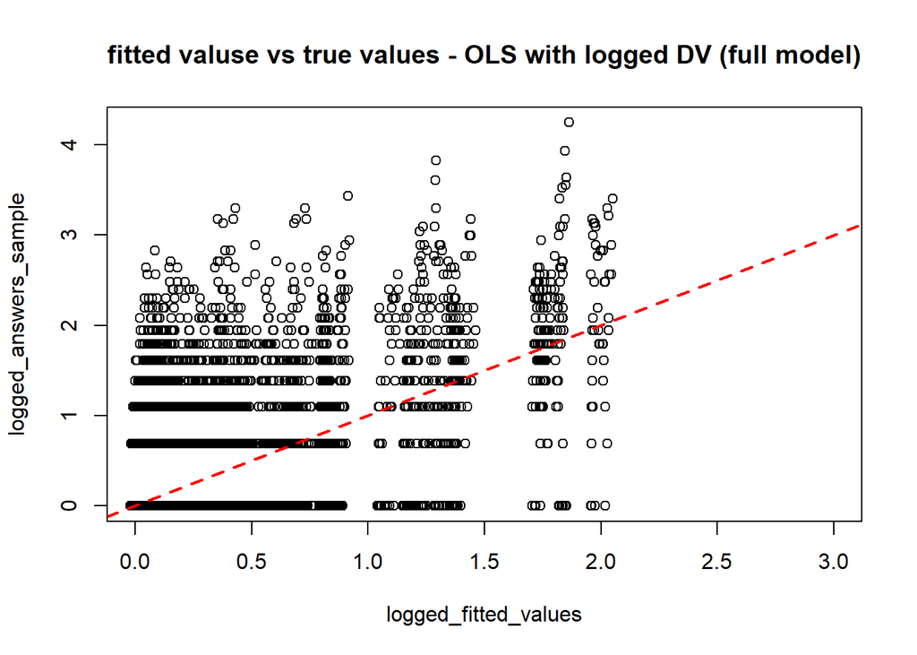

```r
if (!require(countreg)) install.packages("countreg"); library(countreg)#Dangerous, as it overwrites the pscl hurdle models!
#diagnostics
## getting fitted values and comparing them to observed values
logged_fitted_values <- log(w_panel_matched_qual_6m_unalt_b$actions+1) - residuals(ols_logged_fullFEs_matched_unalt_asw_6m)
logged_answers_sample <- log(w_panel_matched_qual_6m_unalt_b$actions+1)
#plot them
plot(logged_fitted_values,logged_answers_sample , xlim = c(0,3), main = "fitted valuse vs true values - OLS with logged DV (full model)")
abline(0, 1, col = 'red', lty = 'dashed', lwd = 2)
```

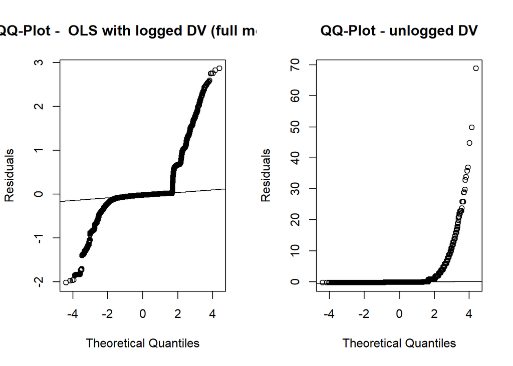

```r
par(mfrow = c(1, 2))
#plot the residuals of the model with fixed effects
qqnorm(residuals(ols_logged_fullFEs_matched_unalt_asw_6m), ylab = 'Residuals', main = "QQ-Plot -  OLS with logged DV (full model)")
qqline(residuals(ols_logged_fullFEs_matched_unalt_asw_6m))

#plot the residuals of the model without fixed effects
qqnorm(residuals(ols_matched_unalt_asw_6m), ylab = 'Residuals', main = "QQ-Plot - unlogged DV")
qqline(residuals(ols_matched_unalt_asw_6m))
```

```r
par(mfrow = c(1, 1))
```

The above shows, that as already established, the fitted values are barely representative of the actual answers using the OLS specification with a logged dependent variable, even with fixed effects. Furthermore, the qq plots suggest that the DV is highly non-normally distributed. Both illustrations provide evidence for a count model providing more reliable predictive power and thus a more suitable fit for the modeled dv. Below, rootograms of the count models are provided to offer insight into which is best able to predict the in-sample answers.

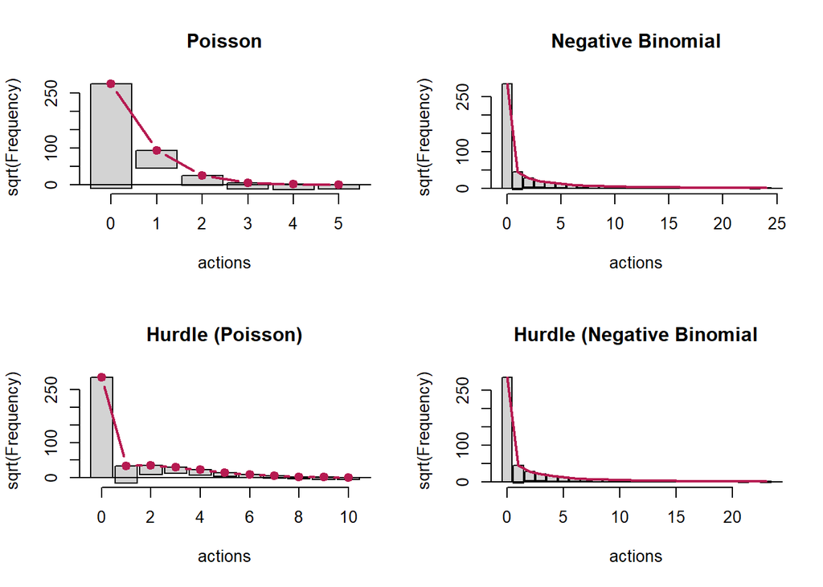

```r
par(mfrow = c(2, 2))

#plot rootograms for different models, starting with poissons and NB models without fixed effects
countreg::rootogram(pois_matched_unalt_asw_6m, main = "Poisson")
countreg::rootogram(negbi_matched_unalt_asw_6m, main = "Negative Binomial")


#rootograms for the hurdle models
countreg::rootogram(pois_h_matched_unalt_asw_6m, main = "Hurdle (Poisson)")
countreg::rootogram(negbi_h_matched_unalt_asw_6m, main = "Hurdle (Negative Binomial")
```

```r
par(mfrow = c(1, 1))
```

inspecting the rootograms above, it can be observed that the hurdle models display less fitting errors, while the negative binomial versions perform better than the poisson model. Both is no surprise given the combination of 0 inflation and overdispersion in the distribution of the dv of interest. A rootogram plotting the models with fixed effects was not available

An investigation of the outliers for 2 of the models, the OLS with the logged dependent variable as well as the negative binomial regression, yielded at least 2 users, 1 from each of the communities, that displayed unusually high values of answers, leading them to be flagged as outliers according to studentized residual and cook’s distance values. once again, the above outlier identification functions were not available for the models with fixed effects.

First, find below a table of the top 10 most influential outlier observations in the logged DV OLS specification

```r
#outlier test for ols logged model
outlierTest(ols_logged_matched_unalt_asw_6m)
```

```
##       rstudent unadjusted p-value Bonferroni p
## 1942  16.54977         2.0058e-61   1.7062e-56
## 39401 15.30650         8.1385e-53   6.9227e-48
## 10092 14.85253         7.7370e-50   6.5813e-45
## 41052 14.15632         1.9227e-45   1.6355e-40
## 14141 13.97277         2.5590e-44   2.1768e-39
## 30321 13.73805         6.6768e-43   5.6794e-38
## 37323 13.67908         1.5022e-42   1.2778e-37
## 19698 13.23273         6.2199e-40   5.2908e-35
## 17007 13.22209         7.1630e-40   6.0930e-35
## 3005  13.09546         3.8144e-39   3.2446e-34
```

Second, find below a table of the top 10 most influential outlier observations in the negative binomial specification

```r
#outlier test for the negbi models
outlierTest(negbi_matched_unalt_asw_6m) #IDs: 647540000, 283107 identified
```

```
##       rstudent unadjusted p-value Bonferroni p
## 1942  13.62441         2.8670e-42   2.4387e-37
## 39401 11.92890         8.3672e-33   7.1173e-28
## 45590 11.86661         1.7647e-32   1.5011e-27
## 84833 11.77991         4.9548e-32   4.2147e-27
## 82735 11.51379         1.1242e-30   9.5629e-26
## 65344 11.40783         3.8215e-30   3.2507e-25
## 75407 11.26223         2.0159e-29   1.7148e-24
## 79557 10.91516         9.7559e-28   8.2986e-23
## 41052 10.64430         1.8538e-26   1.5769e-21
## 10092 10.61061         2.6602e-26   2.2628e-21
```

```r
#outlier test for the negbi hurdle
  #outlierTest(negbi_h_matched_unalt_asw_6m) ---> not possible with a "hurdle" object
```

Finally, below the visual analysis of outliers in the two model specifications

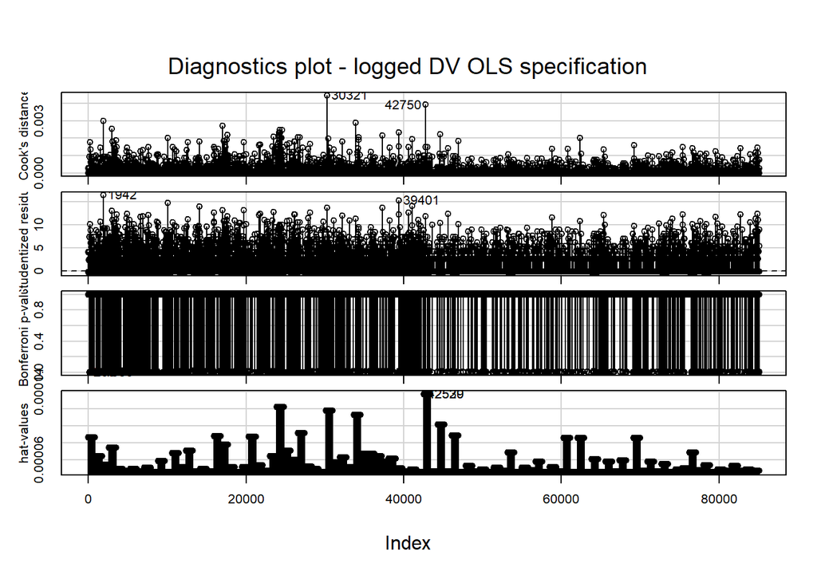

```r
#checking for outliers in the non FE models
par(mfrow = c(1, 2))
infIndexPlot(ols_logged_matched_unalt_asw_6m, main = "Diagnostics plot - logged DV OLS specification") #--> ID: 647540000 identified
```

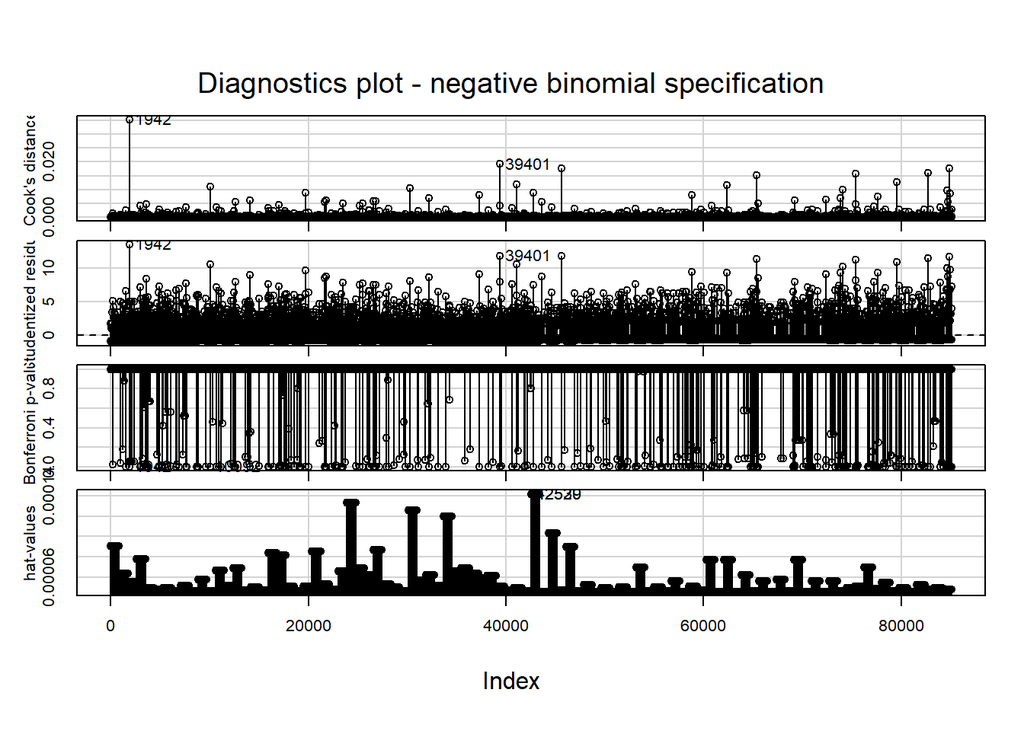

```r
infIndexPlot(negbi_matched_unalt_asw_6m, main = "Diagnostics plot - negative binomial specification") #--> ID: 647540000 identified again
```

```r
par(mfrow = c(1, 1))
```

To test their impact on the coefficients as well as model fit, models with and without fixed effects for the two specifications used to test for outliers were rerun as shown below

```r
### rerunning the models without the outliers -> only the best fitting ones
Oless_w_panel_matched_qual_6m_unalt_b <- w_panel_matched_qual_6m_unalt_b %>% filter(!user_ID %in% c(647540000, 283107))

#logged DV no FEs
ols_logged_Oless_m_unalt_asw_6m <- lm(formula_log_reg, data = Oless_w_panel_matched_qual_6m_unalt_b)
#logged, FEs and clustered standard errors
ols_logged_Oless_fullFEs_m_unalt_asw_6m <- felm(log(actions + 1) ~  did_coeff + questions_per_week|user_ID + as.factor(t_shock_w)|0|user_ID, data = Oless_w_panel_matched_qual_6m_unalt_b)

# poisson - without fixed effects
pois_Oless_m_unalt_asw_6m <- glm(actions ~ group*post_treatment + questions_per_week, family = poisson, data = Oless_w_panel_matched_qual_6m_unalt_b)
# negative binomial - without fixed effects
(theta_matched_Oless <- glm.nb(actions ~ group*post_treatment + questions_per_week, data = Oless_w_panel_matched_qual_6m_unalt_b)$theta)
```

[1] 0.03739692

```r
negbi_Oless_m_unalt_asw_6m <- update(pois_Oless_m_unalt_asw_6m, family = negative.binomial(theta_matched))

#hurdlemodel
negbi_h_Oless_m_unalt_asw_6m <- hurdle(actions ~ group*post_treatment + questions_per_week|answers_per_week, data = Oless_w_panel_matched_qual_6m_unalt_b, dist = "negbin")


stargazer(ols_logged_matched_unalt_asw_6m,
          ols_logged_Oless_m_unalt_asw_6m,
          ols_logged_fullFEs_matched_unalt_asw_6m,
          ols_logged_Oless_fullFEs_m_unalt_asw_6m,
          negbi_matched_unalt_asw_6m,
          negbi_Oless_m_unalt_asw_6m,
          type = "html")
```

|  | *Dependent variable:* |  |  |  |  |  |
| --- | --- | --- | --- | --- | --- | --- |
|  | log(actions + 1) |  |  |  | actions |  |
|  | *OLS* |  | *felm* |  | *glm: Negative Binomial(0.0343)* |  |
|  |  |  |  |  | *link = log* |  |
|  | (1) | (2) | (3) | (4) | (5) | (6) |
| group | 0.072*** | 0.069*** |  |  | 1.428*** | 1.391*** |
|  | (0.006) | (0.006) |  |  | (0.177) | (0.163) |
| post_treatment | 0.006** | 0.005 |  |  | 0.024 | -0.011 |
|  | (0.003) | (0.003) |  |  | (0.098) | (0.090) |
| did_coeff |  |  | -0.041*** | -0.040*** |  |  |
|  |  |  | (0.006) | (0.006) |  |  |
| questions_per_week | 0.001*** | 0.001*** | 0.001*** | 0.001*** | 0.018*** | 0.016*** |
|  | (0.0001) | (0.0001) | (0.0001) | (0.0001) | (0.002) | (0.002) |
| group:post_treatment | -0.042*** | -0.040*** |  |  | -0.800*** | -0.891*** |
|  | (0.004) | (0.003) |  |  | (0.110) | (0.102) |
| Constant | -0.018** | -0.016** |  |  | -3.592*** | -3.583*** |
|  | (0.007) | (0.007) |  |  | (0.227) | (0.210) |
| Observations | 85,062 | 84,965 | 85,062 | 84,965 | 85,062 | 84,965 |
| R<sup>2</sup> | 0.007 | 0.007 | 0.324 | 0.286 |  |  |
| Adjusted R<sup>2</sup> | 0.007 | 0.007 | 0.309 | 0.270 |  |  |
| Log Likelihood |  |  |  |  | -22,671.710 | -21,948.520 |
| Akaike Inf. Crit. |  |  |  |  | 45,353.410 | 43,907.040 |
| Residual Std. Error | 0.253 (df = 85057) | 0.243 (df = 84960) | 0.211 (df = 83241) | 0.208 (df = 83146) |  |  |
| F Statistic | 146.415*** (df = 4; 85057) | 156.141*** (df = 4; 84960) |  |  |  |  |
| *Note:* | p<0.1; p<0.05; p<0.01 |  |  |  |  |  |

### Pretrend analysis

To test whether the parallel pretrends assumption holds, the following equation is used:

$$y_{it} = \beta_{1}*group_{i} + \beta_{2}(group_{i}*week_{t}) + \beta_{3}questions_{t} + \alpha_{t} + \gamma_{i} + \epsilon_{it}$$

For the difference in difference coefficient to be interpreted as causal, the required assumption is that the pretrends of the dependent variable are comparable in both groups. I.e. they don’t need to be the same in level, however there should not be any serious deviations in changes over time between the two treated and comparison groups. Here, $\beta_{2}$ gives a point estimate of the difference in answering behavior between the treatment and control group

Below, the point estimates and standard errors for the $\beta_{2}$ coefficient are presented for the poisson regression with fixed effects specification - the most suitable model given the data structure aside from the negative binomial specification. It has to be said that it was not possible to estimate pretrends for the negative binomial models with fixed effects or the hurdle models as they did not converge - the implications of this is currently not clear to the author. In addition, the pretrends using the OLS model with the logged DV variable, including full fixed effects and errors clustered at the individual level are presented

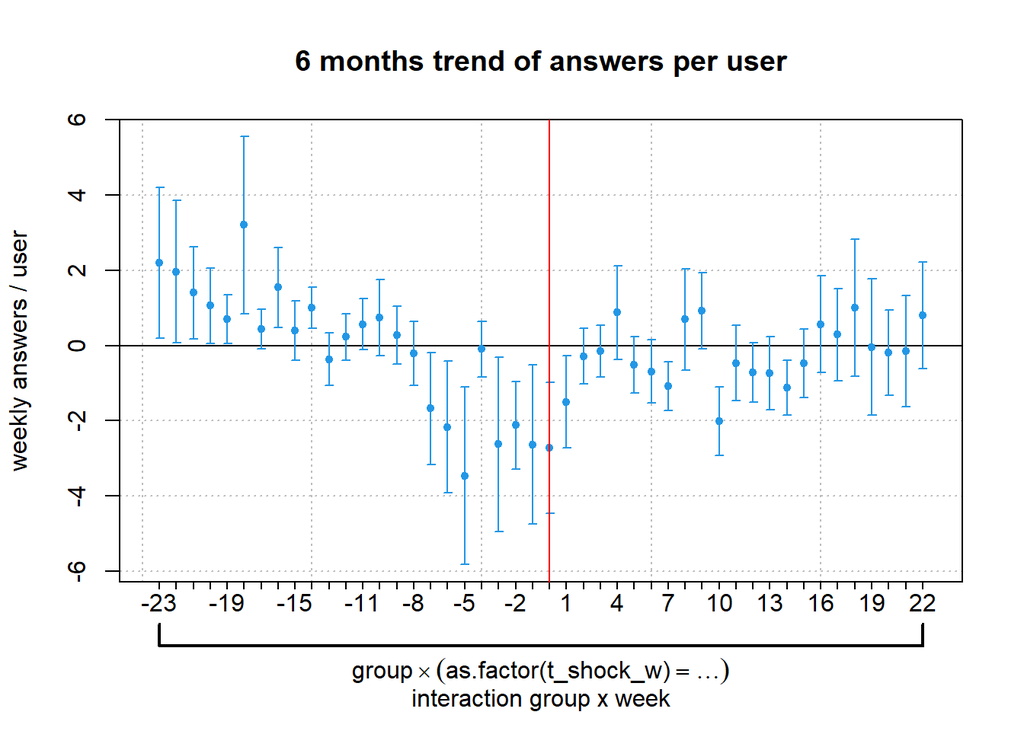

```r
#Poisson with fixed effects --> NB with FE don't work, can't estimate SEs. need to opt for poisson
pretrend_pois_FEs_m_unalt_asw_6m <- fepois(actions ~ group*as.factor(t_shock_w) + questions_per_week|as.factor(user_ID) + as.factor(t_shock_w), data = w_panel_matched_qual_6m_unalt_b)

#plot the pretrends
fixest::coefplot(pretrend_pois_FEs_m_unalt_asw_6m, keep = ":",
                                                            col = 4,
                                                            main = "6 months trend of answers per user",
                                                            xlab = "interaction group x week",
                                                            ylab = "weekly answers / user")
abline(v=24, col="red")
```

For optimal pretrends one would want the confidence intervals in each period to cross the horizontal line at y=0, implying that statistically, difference in the change from period to period in each group is equal to 0 (Barbosu and Gans 2017). As is evident from the pretrend analysis above using the poisson regression with fixed effects on the week and individual level specification, pretrends are not optimal when comparing the two groups, raising considerable doubt about whether the difference-in-difference coefficient can be interpreted as representing a causal effect of the symbolic award introduction.

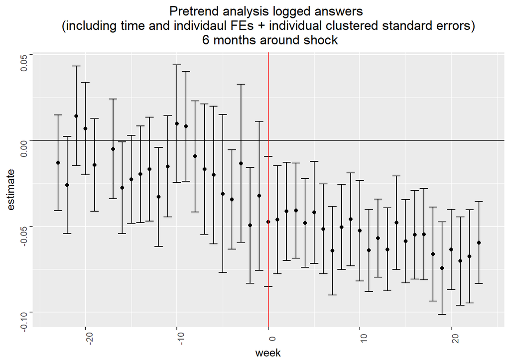

```r
#pretrends for answers using the log transformed dependent variable - including individual fixed effects

pretrends_asw_matched_unalt_log <- felm(log(actions+1) ~ group*as.factor(t_shock_w) + questions_per_week|as.factor(t_shock_w)+user_ID|0|user_ID, data = w_panel_matched_qual_6m_unalt_b)

#plot the pretrends

tidy_log_pretrends <- tidy(pretrends_asw_matched_unalt_log, conf.int = T)

tidy_log_pretrends$week <-  c(-72:23)


tidy_log_pretrends %>% filter(is.na(estimate) == F, term != "questions_per_week") %>%
  ggplot(aes(x = week, y = estimate)) +
  geom_point() +
  geom_errorbar(aes(ymin = conf.low, ymax = conf.high)) +
  geom_hline(yintercept = 0) +
  geom_vline(xintercept = 0, color = "red") +
  labs(title = "Pretrend analysis logged answers \n (including time and individaul FEs + individual clustered standard errors) \n 6 months around shock") +
  theme(plot.title = element_text(hjust = 0.5),
        axis.text = element_text(angle = 90))
```

The pretrends above, which are based on the model specification using the logged dependent variable, including individual and time fixed effects as well as clustering the standard errors on the individual, while not perfect, provide better arguments for interpreting the difference in difference coefficient of the model as causal (it should be noted here, that for the week*group interaction in period -18, no coefficient was calculated).

In summary, while the distribution of the dependent variable suggests that a count model, specifically one that accounts for overdispersion and zero inflation, should be used, the pretrends do not allow for the causal interpretation of the DiD coefficient. Taking into account that the pretrends look more promising when using the logged DV specification for the pretrend analysis, in addition to the fact that the DiD coefficient is negative and significant in all but the models accounting for 0 inflation (of which the interpretation is unclear as explained above), at best a tentative conclusion can be drawn about the causal effect of the introduction of the symbolic awards. In addition to the fact that it is unclear how the hurdle model can properly be applied to panel data, pretrend checks were not able to be shown as no coefficient could be calculated for the week*group interaction effect. Hence, until a solution is found for this issue, it can’t be assumed that the positive change in contribution behavior suggested by the coefficients of the hurdle model are causally related to the introduction of the symbolic awards.

# Concluding remarks

In conclusion, the above analysis does allow us to reject the 0 hypothesis of symbolic award introduction not leading to any significant change in weekly user answering behavior when only considering the coefficients of the difference in difference models. However, taking into account that analysis of the pretrends does not allow us to assert that the parallel trends assumption holds in our context, we cannot claim that the negative effect found by our difference in difference specification is causally related to the award introduction.

A number of issues of this study can be listed, both from a data and performance analysis standpoint. A large issue concerning the data is, that we cannot confidently claim that some other event which occurred before the treatment introduction caused the decline in answers of the treatment group as of this moment. Furthermore, it transpired that the distribution of individual answering behavior in either community is quite different. While in both communities, answering behavior demonstrates power law properties, in that there are a very large number of barely active users and a very small number of highly active users, this effect seems to be especially pronounced in the treated community. We tried to adjust for this using matching procedures, however it seems that while pretrends did improve compared to the unmatched data, the improvement isn’t sufficient to assert parallel trends before treatment for both communities

From an analysis side, technical issues prevented the provision of a full picture. Within the extent of this statistical report, it wasn’t possible to find a way to apply a hurdle model that reflected the panel dynamics of the data, hence the interpretation of the coefficient (in addition to the calculation of pretrends) proved difficult. Furthermore, it wasn’t possible to assess how well negative binomial models deal with panel data.

Finally, there are numerous extensions and robustness checks that could have been done but weren’t conducted within this statistical report. There are a number of alternative matching algorithms that could have been tried as well as different matching variable combinations that could have been tested beyond what has been done within this report. In addition, the propensity scores could be used as weights instead of using matching as a means of sample readjustment. A further route to try could be entropy balancing. These matched, or adjusted, samples could then be used to choose a sample for the difference in difference models which offers the most suitable pretrends. Finally, robustness checks that test results based on different time periods around the shock as well as running models where the period of the shock is arbitrarily selected, are currently missing.

Beyond addressing the issues pointed out above, a number of extensions to the current research question will be investigated in the future. The change in answer quality and effort can be measured given the data available on the number of likes and words/answer respectively. In addition, it is worth looking into whether member type can be included as a moderator, depending on the pre-treatment activity level of the users.

# Remarks that I would particularly value feedback on

- the pretrends: Is the way I am assessing the parallel trends assumption the only viable way? If the count regression model is the best fitting model but the pretrends as shown aren’t parallel, does the justification using pretrends from logged OLS model make any sense?
- Are there any suggested count models to use when I have 0 inflated panel data? Unsure if hurdle/zero inflated models or negative binomial models can deal with panel data
- the DiD models on the count models are huge (without hurdle specficiation), suggesting a nearly 60% decrease in average answering behavior after the shock. This is not evident from inspecting the pretrends. is the large portion of 0s in the data + the fact that there are more 0s present in the treatment group than the control group after the shock the reason for this? I.e. similar to when adding an extremely low constant (e.g. 0.00001 instead of 1) to the dv variable before logging it leads to the did coefficient changing from a 5% decrease in average answering behavior to a 60% decrease in average answering behavior

# References

Anderson, Ashton, Daniel Huttenlocher, Jon Kleinberg, and Jure Leskovec. 2013. “Steering User Behavior with Badges$\ast$: May 13 - 17, 2013, Rio de Janeiro, Brazil.” In *Proceedings of the 22nd International Conference on the World Wide Web*.

Barbosu, Sandra, and Joshua Gans. 2017. “Storm Crowds: Evidence from Zooniverse on Crowd Contribution Design.” In *NBER Working Paper Series*. Vol. No. 23955.

Chen, Yan, Teck-Hua Ho, and Yong-Mi Kim. 2010. “Knowledge Market Design: A Field Experiment at Google Answers.” *Journal of Public Economic Theory* 12 (4): 641–64.

David, P. A., and F. Rullani. 2008. “Dynamics of Innovation in an Open Source Collaboration Environment: Lurking, Laboring, and Launching Floss Projects on Sourceforge.” *Industrial and Corporate Change* 17 (4): 647–710. https://doi.org/10.1093/icc/dtn026.

Faraj, Samer, Georg von Krogh, Eric Monteiro, and Karim R. Lakhani. 2016. “Special Section Introduction—Online Community as Space for Knowledge Flows.” *Information Systems Research* 27 (4): 668–84.

Fjeldstad, Øystein D., Charles C. Snow, Raymond E. Miles, and Christopher Lettl. 2012. “The Architecture of Collaboration.” *Strategic Management Journal* 33 (6): 734–50. https://doi.org/10.1002/smj.1968.

Frey, Bruno S., and Jana Gallus. 2017. “Towards an Economics of Awards.” *Journal of Economic Surveys* 31 (1): 190–200. https://doi.org/10.1111/joes.12127.

Gallus, Jana. 2017. “Fostering Public Good Contributions with Symbolic Awards: A Large-Scale Natural Field Experiment at Wikipedia.” *Management Science* 63 (12): 3999–4015.

Gneezy, Uri, Stephan Meier, and Pedro Rey-Biel. 2011. “When and Why Incentives (Don’t) Work to Modify Behavior.” *Journal of Economic Perspectives* 25 (4): 191–210. https://doi.org/10.1257/jep.25.4.191.

Goes, Paulo B., Chenhui Guo, and Mingfeng Lin. 2016. “Do Incentive Hierarchies Induce User Effort? Evidence from an Online Knowledge Exchange.” *Information Systems Research* 27 (3): 497–516.

Jensen, Morten Berg, Christoph Hienerth, and Christopher Lettl. 2014. “Forecasting the Commercial Attractiveness of User-Generated Designs Using Online Data: An Empirical Study Within the Lego User Community.” *Journal of Product Innovation Management* 31 (2): 75–93. https://doi.org/10.1111/jpim.12193.

Jeppesen, Lars Bo, and Lars Frederiksen. 2006. “Why Do Users Contribute to Firm-Hosted User Communities? The Case of Computer-Controlled Music Instruments.” *Organization Science* 17 (1): 45–63. https://doi.org/10.1287/orsc.1050.0156.

Kraut, Robert E., Paul Resnick, and Sara Kiesler. n.d. *Building Successful Online Communities: Evidence-Based Social Design*. Cambridge (Mass.); London: MIT.

Lappas, Theodoros, Chrysanthos Dellarocas, and Neda Derakhshani. 2017. “Reputation and Contribution in Online Question-Answering Communities.”

Lerner, Josh, and Jean Tirole. 2002. “Some Simple Economics of Open Source.” *Journal of Industrial Economics* 50 (2): 197. http://content.ebscohost.com/ContentServer.asp?T=P&P=AN&K=6578923&EbscoContent=dGJyMNLr40Sep7A4zOX0OLCmr1GeprFSsqy4SbCWxWXS&ContentCustomer=dGJyMPGut0m1qq5OuePfgeyx%2BEu3q64A&D=buh.

Liu, De, Radhika Santhanam, and Jane Webster. 2017. “Toward Meaningful Engagement: A Framework for Design and Research of Gamified Information Systems.” *MIS Quarterly* 41 (4): 1011–34.

Ma, Meng, and Ritu Agarwal. 2007. “Through a Glass Darkly: Information Technology Design, Identity Verification, and Knowledge Contribution in Online Communities.” *Information Systems Research* 18 (1): 42–67. https://doi.org/10.1287/isre.1070.0113.

Oh, Wonseok, and Sangyong Jeon. 2007. “Membership Herding and Network Stability in the Open Source Community the Ising Perspective.” *Management Science* 53 (7): 1086–1101. https://doi.org/10.1287/mnsc.1060.0623.

Park, Hyunwoo, and Jeongsik Jay Lee. 2015. “An (Almost) Free Lunch? Social Recognition and Knowledge Sharing Behavior in a Virtual Community.” *Academy of Management Proceedings* 2015 (1): 1. https://doi.org/10.5465/AMBPP.2015.184.

Puranam, Panish, Oliver Alexy, and Markus Reitzig. 2014. “What’s New About New Forms of Organizing.” *Academy of Management Review* 39 (2): 162–80.

Ray, Soumya, Sung S. Kim, and James G. Morris. 2014. “The Central Role of Engagement in Online Communities.” *Information Systems Research* 25 (3): 528–46.

Robinson, Carly D., Jana Gallus, Monica G. Lee, and Todd Rogers. 2018. “The Demotivating Effect (and Unintended Message) of Awards: HKS Working Paper No Rwp19-020.” *SSRN Electronic Journal*.

Stanko, Michael A. 2016. “Toward a Theory of Remixing in Online Innovation Communities.” *Information Systems Research* 27 (4): 773–91. https://doi.org/10.1287/isre.2016.0650.

Sun, Na, Patrick Pei-Luen Rau, and Liang Ma. 2014. “Understanding Lurkers in Online Communities: A Literature Review.” *Computers in Human Behavior* 38: 110–17. https://doi.org/10.1016/j.chb.2014.05.022.

van Mierlo, Trevor. 2014. “The 1% Rule in Four Digital Health Social Networks: An Observational Study.” *Journal of Medical Internet Research* 16 (2): e33. https://doi.org/10.2196/jmir.2966.

von Krogh, Georg, Haefliger, Spaeth, and Wallin. 2012. “Carrots and Rainbows: Motivation and Social Practice in Open Source Software Development.” *MIS Quarterly* 36 (2): 649. https://doi.org/10.2307/41703471.

von Krogh, Georg, Sebastian Spaeth, and Karim R. Lakhani. 2003. “Community, Joining, and Specialization in Open Source Software Innovation: A Case Study.” *Research Policy* 32 (7): 1217–41. https://doi.org/10.1016/S0048-7333(03)00050-7.

Wasko, Molly McLure, and Samer Faraj. 2005. “Why Should I Share? Examining Social Capital and Knowledge Contribution in Electronic Networks of Practice.” *Management Information Systems Quarterly* 29 (1): 35–57. https://pdfs.semanticscholar.org/158e/131aac4ed0751a0e6752f8618b4528da879b.pdf.

Wasko, Molly McLure, Robin Teigland, and Samer Faraj. 2009. “The Provision of Online Public Goods: Examining Social Structure in an Electronic Network of Practice.” *Decision Support Systems* 47 (3): 254–65. https://doi.org/10.1016/j.dss.2009.02.012.

Yeow, Adrian, Steven Johnson, and Samer Faraj. 2006. “Lurking: Legitimate or Illegitimate Peripheral Participation?” *ICIS 2006 Proceedings*. https://aisel.aisnet.org/icis2006/62.

A work by [Alexander Staub](https://github.com/deskreject/)

*alexander.staub@wu.ac.at*